# Project: Identify Customer Segments

In this project, you will apply unsupervised learning techniques to identify segments of the population that form the core customer base for a mail-order sales company in Germany. These segments can then be used to direct marketing campaigns towards audiences that will have the highest expected rate of returns. The data that you will use has been provided by our partners at Bertelsmann Arvato Analytics, and represents a real-life data science task.

This notebook will help you complete this task by providing a framework within which you will perform your analysis steps. In each step of the project, you will see some text describing the subtask that you will perform, followed by one or more code cells for you to complete your work. **Feel free to add additional code and markdown cells as you go along so that you can explore everything in precise chunks.** The code cells provided in the base template will outline only the major tasks, and will usually not be enough to cover all of the minor tasks that comprise it.

It should be noted that while there will be precise guidelines on how you should handle certain tasks in the project, there will also be places where an exact specification is not provided. **There will be times in the project where you will need to make and justify your own decisions on how to treat the data.** These are places where there may not be only one way to handle the data. In real-life tasks, there may be many valid ways to approach an analysis task. One of the most important things you can do is clearly document your approach so that other scientists can understand the decisions you've made.

At the end of most sections, there will be a Markdown cell labeled **Discussion**. In these cells, you will report your findings for the completed section, as well as document the decisions that you made in your approach to each subtask. **Your project will be evaluated not just on the code used to complete the tasks outlined, but also your communication about your observations and conclusions at each stage.**

```python
# import libraries here; add more as necessary
import numpy as np
import pandas as pd
import matplotlib.pyplot as plt
import seaborn as sns

from ast import literal_eval

from sklearn.preprocessing import LabelEncoder
from sklearn.preprocessing import OneHotEncoder
from sklearn.preprocessing import StandardScaler
from sklearn.preprocessing import Imputer
from sklearn.decomposition import PCA
from sklearn.cluster import KMeans

from IPython.display import Image

import datetime

from workspace_utils import active_session
from workspace_utils import keep_awake


# magic word for producing visualizations in notebook
%matplotlib inline
```

### Step 0: Load the Data

Each row of the demographics files represents a single person, but also includes information outside of individuals, including information about their household, building, and neighborhood. You will use this information to cluster the general population into groups with similar demographic properties. Then, you will see how the people in the customers dataset fit into those created clusters. The hope here is that certain clusters are over-represented in the customers data, as compared to the general population; those over-represented clusters will be assumed to be part of the core userbase. This information can then be used for further applications, such as targeting for a marketing campaign.

To start off with, load in the demographics data for the general population into a pandas DataFrame, and do the same for the feature attributes summary. Note for all of the `.csv` data files in this project: they're semicolon (`;`) delimited, so you'll need an additional argument in your [`read_csv()`](https://pandas.pydata.org/pandas-docs/stable/generated/pandas.read_csv.html) call to read in the data properly. Also, considering the size of the main dataset, it may take some time for it to load completely.

Once the dataset is loaded, it's recommended that you take a little bit of time just browsing the general structure of the dataset and feature summary file. You'll be getting deep into the innards of the cleaning in the first major step of the project, so gaining some general familiarity can help you get your bearings.

```python
# Load in the general demographics data.
azdias = pd.read_csv('Udacity_AZDIAS_Subset.csv', sep=';')

# Load in the feature summary file.
feat_info = pd.read_csv('AZDIAS_Feature_Summary.csv', sep=';')
```

```python
# Check the structure of the data after it's loaded (e.g. print the number of
# rows and columns, print the first few rows).

azdias.head()
```

|  | AGER_TYP | ALTERSKATEGORIE_GROB | ANREDE_KZ | CJT_GESAMTTYP | FINANZ_MINIMALIST | FINANZ_SPARER | FINANZ_VORSORGER | FINANZ_ANLEGER | FINANZ_UNAUFFAELLIGER | FINANZ_HAUSBAUER | ... | PLZ8_ANTG1 | PLZ8_ANTG2 | PLZ8_ANTG3 | PLZ8_ANTG4 | PLZ8_BAUMAX | PLZ8_HHZ | PLZ8_GBZ | ARBEIT | ORTSGR_KLS9 | RELAT_AB |
| --- | --- | --- | --- | --- | --- | --- | --- | --- | --- | --- | --- | --- | --- | --- | --- | --- | --- | --- | --- | --- | --- |
| 0 | -1 | 2 | 1 | 2.0 | 3 | 4 | 3 | 5 | 5 | 3 | ... | NaN | NaN | NaN | NaN | NaN | NaN | NaN | NaN | NaN | NaN |
| 1 | -1 | 1 | 2 | 5.0 | 1 | 5 | 2 | 5 | 4 | 5 | ... | 2.0 | 3.0 | 2.0 | 1.0 | 1.0 | 5.0 | 4.0 | 3.0 | 5.0 | 4.0 |
| 2 | -1 | 3 | 2 | 3.0 | 1 | 4 | 1 | 2 | 3 | 5 | ... | 3.0 | 3.0 | 1.0 | 0.0 | 1.0 | 4.0 | 4.0 | 3.0 | 5.0 | 2.0 |
| 3 | 2 | 4 | 2 | 2.0 | 4 | 2 | 5 | 2 | 1 | 2 | ... | 2.0 | 2.0 | 2.0 | 0.0 | 1.0 | 3.0 | 4.0 | 2.0 | 3.0 | 3.0 |
| 4 | -1 | 3 | 1 | 5.0 | 4 | 3 | 4 | 1 | 3 | 2 | ... | 2.0 | 4.0 | 2.0 | 1.0 | 2.0 | 3.0 | 3.0 | 4.0 | 6.0 | 5.0 |

5 rows × 85 columns

```python
azdias.shape
```

```
(891221, 85)
```

```python
feat_info.head()
```

|  | attribute | information_level | type | missing_or_unknown |
| --- | --- | --- | --- | --- |
| 0 | AGER_TYP | person | categorical | [-1,0] |
| 1 | ALTERSKATEGORIE_GROB | person | ordinal | [-1,0,9] |
| 2 | ANREDE_KZ | person | categorical | [-1,0] |
| 3 | CJT_GESAMTTYP | person | categorical | [0] |
| 4 | FINANZ_MINIMALIST | person | ordinal | [-1] |

```python
feat_info.shape
```

```
(85, 4)
```

> **Tip**: Add additional cells to keep everything in reasonably-sized chunks! Keyboard shortcut `esc --> a` (press escape to enter command mode, then press the 'A' key) adds a new cell before the active cell, and `esc --> b` adds a new cell after the active cell. If you need to convert an active cell to a markdown cell, use `esc --> m` and to convert to a code cell, use `esc --> y`.

## Step 1: Preprocessing

### Step 1.1: Assess Missing Data

The feature summary file contains a summary of properties for each demographics data column. You will use this file to help you make cleaning decisions during this stage of the project. First of all, you should assess the demographics data in terms of missing data. Pay attention to the following points as you perform your analysis, and take notes on what you observe. Make sure that you fill in the **Discussion** cell with your findings and decisions at the end of each step that has one!

#### Step 1.1.1: Convert Missing Value Codes to NaNs

The fourth column of the feature attributes summary (loaded in above as `feat_info`) documents the codes from the data dictionary that indicate missing or unknown data. While the file encodes this as a list (e.g. `[-1,0]`), this will get read in as a string object. You'll need to do a little bit of parsing to make use of it to identify and clean the data. Convert data that matches a 'missing' or 'unknown' value code into a numpy NaN value. You might want to see how much data takes on a 'missing' or 'unknown' code, and how much data is naturally missing, as a point of interest.

**As one more reminder, you are encouraged to add additional cells to break up your analysis into manageable chunks.**

```python
# Create a copy of the original data and use this copy in the analysis
azdias_clean = azdias.copy()
```

##### Find a number of naturally missing data of each column

```python
azdias_naturally_missing = pd.DataFrame(azdias_clean.isnull().sum(), columns=['num_missing'])
azdias_naturally_missing.head()
```

|  | num_missing |
| --- | --- |
| AGER_TYP | 0 |
| ALTERSKATEGORIE_GROB | 0 |
| ANREDE_KZ | 0 |
| CJT_GESAMTTYP | 4854 |
| FINANZ_MINIMALIST | 0 |

```python
azdias_naturally_missing.shape
```

```
(85, 1)
```

##### Replace unknow values in the data set witn NaN

```python
# Create a helper function to help parsing a string value to an int value
def parse_int(strVal):
    ''' Parse input as int. The original string will be return if it cannot be parsed as int
    '''
    try:
        outNum = int(strVal)
    except ValueError:
        outNum = strVal

    return outNum
```

```python
# Identify missing or unknown data values and convert them to NaNs.

# Loop through all rows in feat_info to get value(s) that represent missing/unknown data of each feature
# Then, replace those missing/unknown data with np.NaN
for index, row in feat_info.iterrows():
    # Get the current column name
    cur_attr = row['attribute']

    # Get the current missing value(s) by parsing values inside a string with pattern [val1 (,val2,...)]
    cur_missing = row['missing_or_unknown'].replace('[','').replace(']','').split(',')
    cur_list = []
    for cur_val in cur_missing:
        if cur_val:
            cur_list.append(parse_int(cur_val))

    # Replace the missing value with NaN
    if cur_list:
        azdias_clean[cur_attr].replace(cur_list, np.NaN, inplace=True)
```

```python
# Get a number of missing values after replacing missing values with NaN
azdias_final_missing = pd.DataFrame(azdias_clean.isnull().sum(), columns=['num_missing'])
azdias_final_missing.head()
```

|  | num_missing |
| --- | --- |
| AGER_TYP | 685843 |
| ALTERSKATEGORIE_GROB | 2881 |
| ANREDE_KZ | 0 |
| CJT_GESAMTTYP | 4854 |
| FINANZ_MINIMALIST | 0 |

##### Find differences between a number of missing data after replacing with NaN and naturally missing data

Inspect a number of filling NaN data is greater than 0

```python
diff = azdias_final_missing - azdias_naturally_missing
diff.query('num_missing > 0').sort_values(['num_missing'], ascending=False)
```

|  | num_missing |
| --- | --- |
| TITEL_KZ | 815562 |
| AGER_TYP | 685843 |
| GEBURTSJAHR | 392318 |
| KBA05_BAUMAX | 343200 |
| ALTER_HH | 236768 |
| SHOPPER_TYP | 111196 |
| VERS_TYP | 111196 |
| HEALTH_TYP | 111196 |
| NATIONALITAET_KZ | 108315 |
| PRAEGENDE_JUGENDJAHRE | 108164 |
| LP_LEBENSPHASE_FEIN | 92778 |
| LP_LEBENSPHASE_GROB | 89718 |
| LP_FAMILIE_GROB | 72938 |
| LP_FAMILIE_FEIN | 72938 |
| W_KEIT_KIND_HH | 40386 |
| REGIOTYP | 36868 |
| KKK | 36868 |
| ANZ_HAUSHALTE_AKTIV | 6463 |
| ALTERSKATEGORIE_GROB | 2881 |
| CAMEO_DEUG_2015 | 373 |
| CAMEO_INTL_2015 | 373 |
| CAMEO_DEU_2015 | 373 |
| ARBEIT | 159 |
| RELAT_AB | 159 |
| ORTSGR_KLS9 | 58 |

#### Step 1.1.2: Assess Missing Data in Each Column

How much missing data is present in each column? There are a few columns that are outliers in terms of the proportion of values that are missing. You will want to use matplotlib's [`hist()`](https://matplotlib.org/api/_as_gen/matplotlib.pyplot.hist.html) function to visualize the distribution of missing value counts to find these columns. Identify and document these columns. While some of these columns might have justifications for keeping or re-encoding the data, for this project you should just remove them from the dataframe. (Feel free to make remarks about these outlier columns in the discussion, however!)

For the remaining features, are there any patterns in which columns have, or share, missing data?

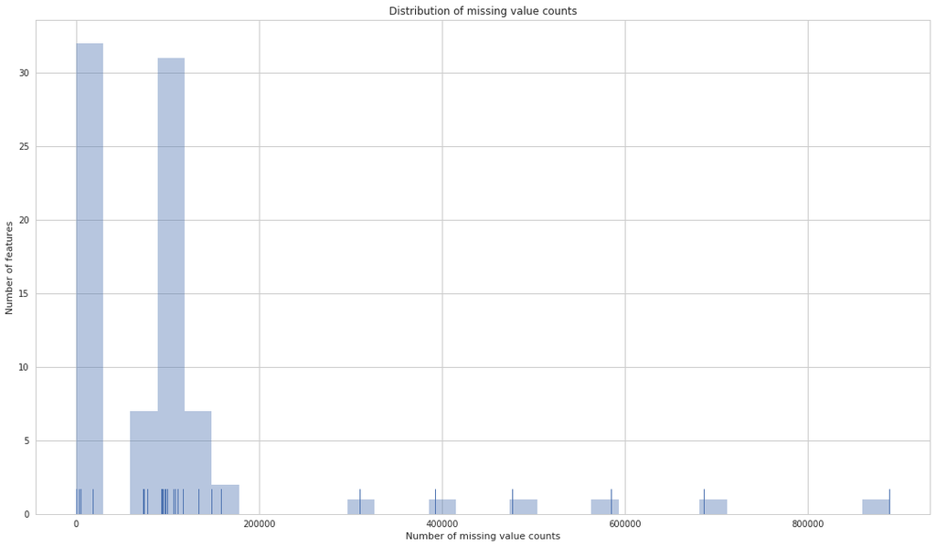

```python
# Perform an assessment of how much missing data there is in each column of the
# dataset.

# Generate a distribution plot to visualize missing data
ax = sns.distplot(azdias_final_missing, bins=30, kde=False, rug=True);
ax.set_title('Distribution of missing value counts');
ax.set_xlabel('Number of missing value counts');
ax.set_ylabel('Number of features');
fig = plt.gcf()
fig.set_size_inches(18.5, 10.5)
```

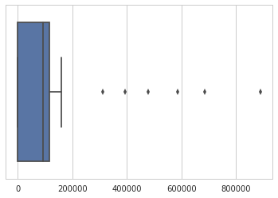

```python
# Generate a boxplot to visualize missing data

sns.set(style="whitegrid")
ax = sns.boxplot(x=azdias_final_missing)
```

```python
# Inspect statistics of missing data
azdias_final_missing.describe()
```

|  | num_missing |
| --- | --- |
| count | 85.000000 |
| mean | 98516.811765 |
| std | 146604.203317 |
| min | 0.000000 |
| 25% | 0.000000 |
| 50% | 93148.000000 |
| 75% | 116515.000000 |
| max | 889061.000000 |

```python
# Investigate patterns in the amount of missing data in each column.


# Find features which are outliers in the boxplot of missing data
# From the boxplot, all outliers have a number of missing data greater than 200000
df_missing_outlier = azdias_final_missing.query('num_missing > 200000').sort_values(['num_missing'], ascending=False)
df_missing_outlier
```

|  | num_missing |
| --- | --- |
| TITEL_KZ | 889061 |
| AGER_TYP | 685843 |
| KK_KUNDENTYP | 584612 |
| KBA05_BAUMAX | 476524 |
| GEBURTSJAHR | 392318 |
| ALTER_HH | 310267 |

Drop columns which have a number of missing data greater that the outlier value

```python
# Remove the outlier columns from the dataset. (You'll perform other data
# engineering tasks such as re-encoding and imputation later.)

drop_columns = df_missing_outlier.index.tolist()
azdias_clean = azdias_clean.drop(drop_columns, axis=1)
```

```python
# Inspect data after droppoing columns to find patterns
with pd.option_context('display.max_rows', 300, 'display.max_columns', 300):
    print(azdias_clean.sample(10))
```

```
        ALTERSKATEGORIE_GROB  ANREDE_KZ  CJT_GESAMTTYP  FINANZ_MINIMALIST  \
566664                   3.0          2            6.0                  3
750425                   3.0          2            5.0                  2
556417                   4.0          2            2.0                  4
23288                    3.0          1            6.0                  3
291997                   2.0          1            3.0                  4
387018                   1.0          1            5.0                  2
511333                   4.0          2            2.0                  5
735295                   1.0          1            5.0                  3
863871                   1.0          2            6.0                  1
768942                   3.0          2            6.0                  1

        FINANZ_SPARER  FINANZ_VORSORGER  FINANZ_ANLEGER  \
566664              4                 3               5
750425              3                 4               1
```

[output cut: 200 more lines]

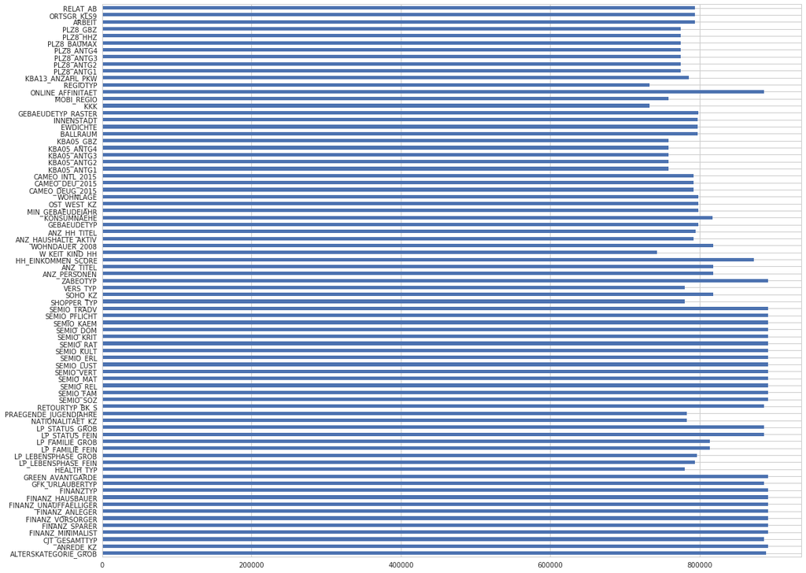

```python
# Create a bar plot to visualize missing data
azdias_clean.count(axis='rows').plot(kind='barh')
fig = plt.gcf()
fig.set_size_inches(18.5, 15)
```

From the bar chart and sampled data, we can see a pattern that all features related to cell features which are 'PLZ8 macro-cell features', 'RR4 micro-cell features', 'RR3 micro-cell features' groups will have missing data if data for a particular observation is unknown

#### Discussion 1.1.2: Assess Missing Data in Each Column

The histogram and box plot of missing values show that there are around 98500 missing values in average for each feature. However, we are seeing outliers of missing values in the 'TITEL_KZ', 'AGER_TYP', 'KK_KUNDENTYP', 'KBA05_BAUMAX', 'GEBURTSJAHR', and 'ALTER_HH' columns and they are removed and they will be used in the next section in this project.

After removing the outliers, from the bar chart and sampled data, we can see a pattern that all features related to cell features which are 'PLZ8 macro-cell features', 'RR4 micro-cell features', 'RR3 micro-cell features' groups where the whole group will share missing data for the same record (e.g. all features in that group will be missing data)

#### Step 1.1.3: Assess Missing Data in Each Row

Now, you'll perform a similar assessment for the rows of the dataset. How much data is missing in each row? As with the columns, you should see some groups of points that have a very different numbers of missing values. Divide the data into two subsets: one for data points that are above some threshold for missing values, and a second subset for points below that threshold.

In order to know what to do with the outlier rows, we should see if the distribution of data values on columns that are not missing data (or are missing very little data) are similar or different between the two groups. Select at least five of these columns and compare the distribution of values.

- You can use seaborn's [`countplot()`](https://seaborn.pydata.org/generated/seaborn.countplot.html) function to create a bar chart of code frequencies and matplotlib's [`subplot()`](https://matplotlib.org/api/_as_gen/matplotlib.pyplot.subplot.html) function to put bar charts for the two subplots side by side.
- To reduce repeated code, you might want to write a function that can perform this comparison, taking as one of its arguments a column to be compared.

Depending on what you observe in your comparison, this will have implications on how you approach your conclusions later in the analysis. If the distributions of non-missing features look similar between the data with many missing values and the data with few or no missing values, then we could argue that simply dropping those points from the analysis won't present a major issue. On the other hand, if the data with many missing values looks very different from the data with few or no missing values, then we should make a note on those data as special. We'll revisit these data later on. **Either way, you should continue your analysis for now using just the subset of the data with few or no missing values.**

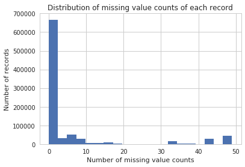

```python
# How much data is missing in each row of the dataset?

# Inspect a distribution of missing data of each record
df_row_num_missing_cols = len(azdias_clean.columns) - azdias_clean.count(axis=1)
df_row_num_missing_cols.hist(bins=20);

plt.title('Distribution of missing value counts of each record');
plt.xlabel('Number of missing value counts');
plt.ylabel('Number of records');
```

```python
# Inspect statistics of missing data
df_row_num_missing_cols.describe()
```

```
count    891221.000000
mean          5.649894
std          13.234687
min           0.000000
25%           0.000000
50%           0.000000
75%           3.000000
max          49.000000
dtype: float64
```

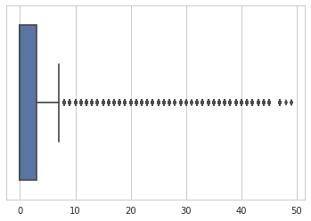

```python
# Inspect a boxplot of missing data
ax = sns.boxplot(x=df_row_num_missing_cols)
```

```python
# Write code to divide the data into two subsets based on the number of missing
# values in each row.

# Based on the boxplot above, most rows have less than 10 missing features.
# Hence, use it to divide the data into two subsets

def find_outlier_value(df_in):
    '''
    Find the high outlier value (Q3 + 1.5*IQR) of the input numpy Series
    '''
    q1 = df_in.quantile(0.25)
    q3 = df_in.quantile(0.75)
    iqr = q3-q1  #Interquartile range
    fence_high = q3+1.5*iqr

    return fence_high

threshold_num_rows = find_outlier_value(df_row_num_missing_cols)
print('Threshold to divide data: ', threshold_num_rows)

df_subset1 = azdias_clean[df_row_num_missing_cols <= threshold_num_rows]
df_subset2 = azdias_clean[df_row_num_missing_cols > threshold_num_rows]
```

```
Threshold to divide data:  7.5
```

```python
# Size of subset1
df_subset1.shape
```

```
(747109, 79)
```

```python
# Size of subset2
df_subset2.shape
```

```
(144112, 79)
```

```python
# Compare the distribution of values for at least five columns where there are
# no or few missing values, between the two subsets.
```

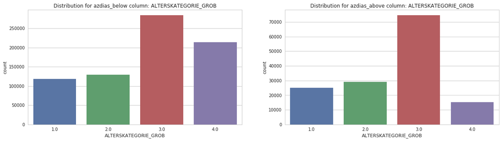

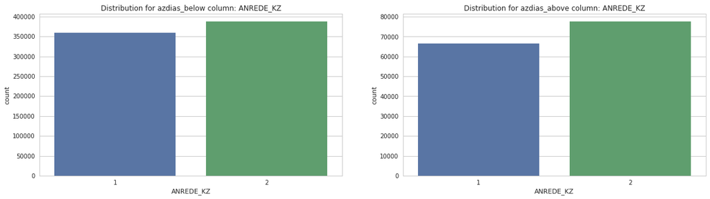

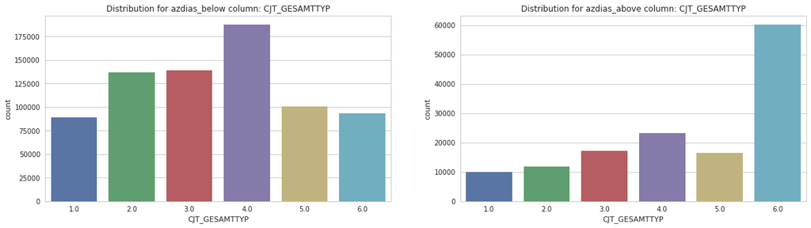

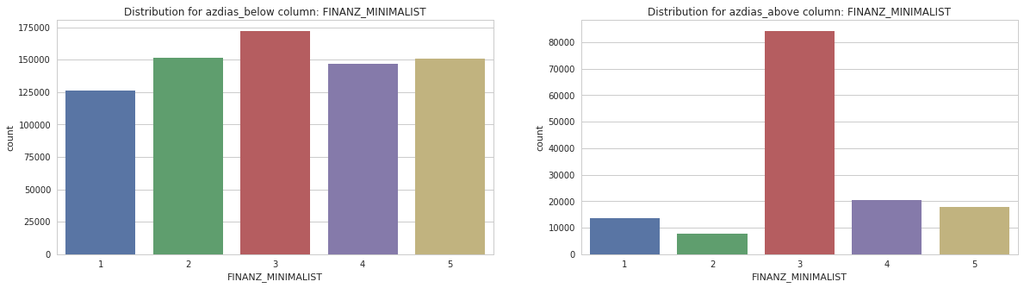

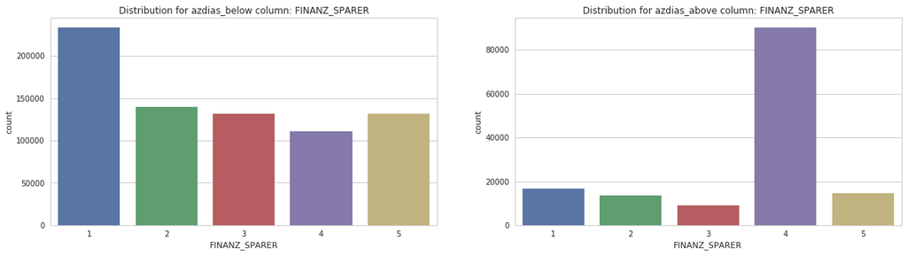

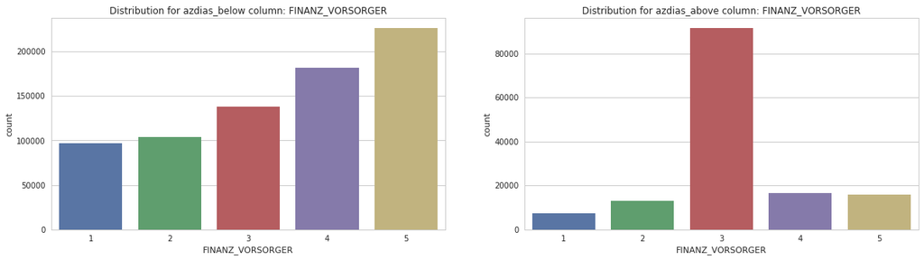

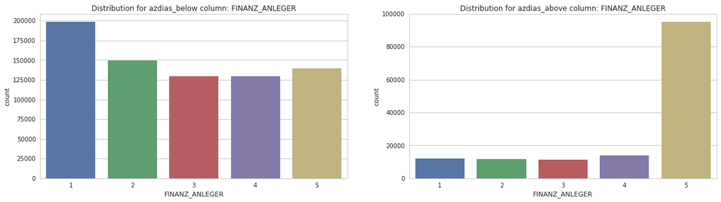

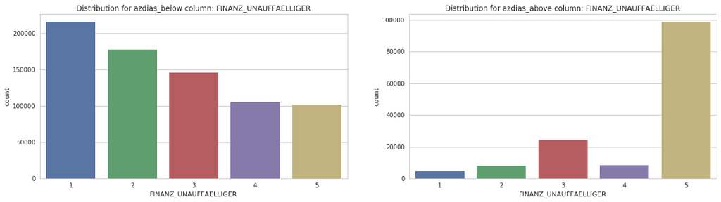

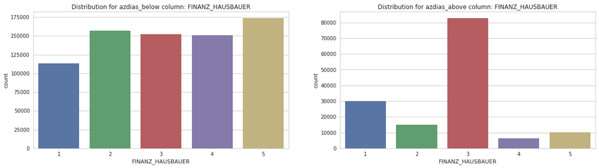

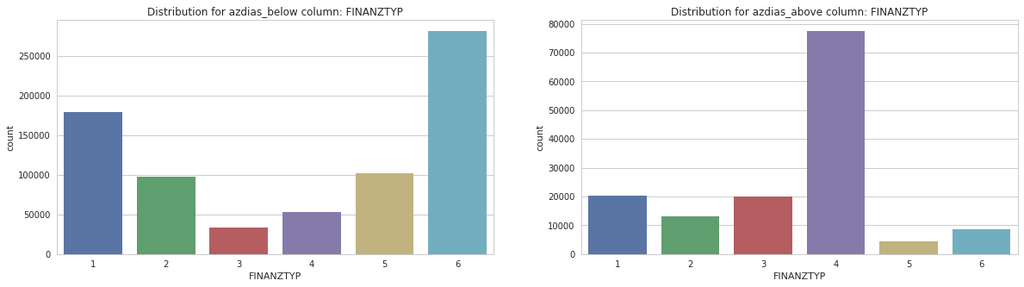

```python
def compare_counts(col):
    plt.figure(figsize=(20, 5))
    plt.subplot(1,2,1)
    sns.countplot(df_subset1[col][df_subset1[col].notnull()], label='below')
    plt.title('Distribution for azdias_below column: {}'.format(col))
    plt.subplot(1,2,2)
    sns.countplot(df_subset2[col][df_subset2[col].notnull()], label='above')
    plt.title('Distribution for azdias_above column: {}'.format(col))

for col in azdias_clean.columns[:10]:
    compare_counts(col)
```

We will be using only data in the df_subset1 in the next steps of the analysis based on the instruction in Step 1.1.3

```python
azdias_clean = df_subset1
```

```python
# Find a number of rows after dropping all missing data
azdias_clean.shape
```

```
(747109, 79)
```

#### Discussion 1.1.3: Assess Missing Data in Each Row

Based on the side-by-side countplots above, it turns out that there are a few features that have diffent countplot shapes which are 'CJT_GESAMTTYP', 'FINANZ_MINIMALIST', 'FINANZ_SPARER', 'FINANZ_VORSORGER', 'FINANZ_ANLEGER', 'FINANZ_UNAUFFAELLIGER', 'FINANZ_HAUSBAUER', 'FINANZTYP' and this represent that those features are qualitatively different from data with few or no missing values.

Another interesting point about those columns is that almost all of those discrepencies are related to Financial Topology data.

### Step 1.2: Select and Re-Encode Features

Checking for missing data isn't the only way in which you can prepare a dataset for analysis. Since the unsupervised learning techniques to be used will only work on data that is encoded numerically, you need to make a few encoding changes or additional assumptions to be able to make progress. In addition, while almost all of the values in the dataset are encoded using numbers, not all of them represent numeric values. Check the third column of the feature summary (`feat_info`) for a summary of types of measurement.

- For numeric and interval data, these features can be kept without changes.
- Most of the variables in the dataset are ordinal in nature. While ordinal values may technically be non-linear in spacing, make the simplifying assumption that the ordinal variables can be treated as being interval in nature (that is, kept without any changes).
- Special handling may be necessary for the remaining two variable types: categorical, and 'mixed'.

In the first two parts of this sub-step, you will perform an investigation of the categorical and mixed-type features and make a decision on each of them, whether you will keep, drop, or re-encode each. Then, in the last part, you will create a new data frame with only the selected and engineered columns.

Data wrangling is often the trickiest part of the data analysis process, and there's a lot of it to be done here. But stick with it: once you're done with this step, you'll be ready to get to the machine learning parts of the project!

```python
# How many features are there of each data type?

feat_info.groupby('type').size().sort_values(ascending=False)
```

```
type
ordinal        49
categorical    21
numeric         7
mixed           7
interval        1
dtype: int64
```

```python
# Inspect a column with the "interval" type

feat_info.query('type == "interval"')
```

|  | attribute | information_level | type | missing_or_unknown |
| --- | --- | --- | --- | --- |
| 43 | ALTER_HH | household | interval | [0] |

#### Step 1.2.1: Re-Encode Categorical Features

For categorical data, you would ordinarily need to encode the levels as dummy variables. Depending on the number of categories, perform one of the following:

- For binary (two-level) categoricals that take numeric values, you can keep them without needing to do anything.
- There is one binary variable that takes on non-numeric values. For this one, you need to re-encode the values as numbers or create a dummy variable.
- For multi-level categoricals (three or more values), you can choose to encode the values using multiple dummy variables (e.g. via [OneHotEncoder](http://scikit-learn.org/stable/modules/generated/sklearn.preprocessing.OneHotEncoder.html)), or (to keep things straightforward) just drop them from the analysis. As always, document your choices in the Discussion section.

```python
# Assess categorical variables: which are binary, which are multi-level, and
# which one needs to be re-encoded?

info_cat_type = feat_info.query('type == "categorical"')
info_mixed_type = feat_info.query('type == "mixed"')
```

```python
# Get a list of columns of 'categorical' and 'mixed' types
columns_cat = info_cat_type['attribute'].tolist()
columns_mixed = info_mixed_type['attribute'].tolist()
```

```python
# Exclude dropped columns
columns_cat_final = [cur_column for cur_column in columns_cat if cur_column not in drop_columns]
columns_mixed_final = [cur_column for cur_column in columns_mixed if cur_column not in drop_columns]
```

```python
def get_unique_values_for_columns(df, column_list):
    '''
    Get a number of unique values for the specified column_list
    '''
    unique_vals = {}

    for cur_column in column_list:
        cur_unique_vals = df[cur_column].dropna().unique()
        unique_vals[cur_column] = cur_unique_vals

    return unique_vals
```

```python
# Get unique values of each column

cat_unique = get_unique_values_for_columns(azdias_clean, columns_cat_final)
mixed_unique = get_unique_values_for_columns(azdias_clean, columns_mixed_final)
```

```python
# Inspect unique values of each 'categorical' column
cat_unique
```

```
{'ANREDE_KZ': array([2, 1]),
 'CJT_GESAMTTYP': array([ 5.,  3.,  2.,  4.,  1.,  6.]),
 'FINANZTYP': array([1, 6, 5, 2, 4, 3]),
 'GFK_URLAUBERTYP': array([ 10.,   1.,   5.,  12.,   9.,   3.,   8.,  11.,   4.,   7.,   2.,
          6.]),
 'GREEN_AVANTGARDE': array([0, 1]),
 'LP_FAMILIE_FEIN': array([  5.,   1.,  10.,   2.,   7.,  11.,   8.,   4.,   6.,   9.,   3.]),
 'LP_FAMILIE_GROB': array([ 3.,  1.,  5.,  2.,  4.]),
 'LP_STATUS_FEIN': array([  2.,   3.,   9.,   4.,   1.,  10.,   8.,   5.,   6.,   7.]),
 'LP_STATUS_GROB': array([ 1.,  2.,  4.,  5.,  3.]),
 'NATIONALITAET_KZ': array([ 1.,  3.,  2.]),
 'SHOPPER_TYP': array([ 3.,  2.,  1.,  0.]),
 'SOHO_KZ': array([ 1.,  0.]),
 'VERS_TYP': array([ 2.,  1.]),
 'ZABEOTYP': array([5, 3, 4, 1, 6, 2]),
 'GEBAEUDETYP': array([ 8.,  1.,  3.,  2.,  6.,  4.,  5.]),
 'OST_WEST_KZ': array(['W', 'O'], dtype=object),
 'CAMEO_DEUG_2015': array(['8', '4', '2', '6', '1', '9', '7', '5', '3'], dtype=object),
 'CAMEO_DEU_2015': array(['8A', '4C', '2A', '6B', '8C', '4A', '2D', '1A', '1E', '9D', '7A',
        '5D', '9E', '5C', '9B', '1B', '8B', '3D', '4E', '4B', '3C', '5A',
        '7B', '9A', '6D', '6E', '2C', '7C', '9C', '7D', '5E', '1D', '8D',
        '6C', '6A', '5B', '4D', '3A', '2B', '7E', '3B', '6F', '5F', '1C'], dtype=object)}
```

```python
# Inspect unique values of each 'mixed' column
mixed_unique
```

```
{'LP_LEBENSPHASE_FEIN': array([ 21.,   3.,  32.,   8.,   2.,   5.,  10.,   4.,   6.,  23.,  20.,
          1.,  25.,  13.,  18.,  31.,  38.,  35.,  30.,   7.,  22.,  14.,
         29.,  24.,  28.,  37.,  26.,  12.,  39.,  27.,  36.,   9.,  34.,
         33.,  15.,  11.,  40.,  16.,  19.,  17.]),
 'LP_LEBENSPHASE_GROB': array([  6.,   1.,  10.,   2.,   3.,   5.,   7.,  12.,  11.,   9.,   4.,
          8.]),
 'PRAEGENDE_JUGENDJAHRE': array([ 14.,  15.,   8.,   3.,  10.,  11.,   9.,   6.,   4.,   5.,   2.,
          1.,  12.,  13.,   7.]),
 'WOHNLAGE': array([ 4.,  2.,  7.,  3.,  5.,  1.,  8.,  0.]),
 'CAMEO_INTL_2015': array(['51', '24', '12', '43', '54', '22', '14', '13', '15', '41', '34',
        '55', '33', '25', '23', '31', '52', '35', '45', '44', '32'], dtype=object),
 'PLZ8_BAUMAX': array([ 1.,  2.,  4.,  5.,  3.])}
```

```python
# Find a set of columns for binary, binary that needs encoding, and multi-level categoricals
# for the category data

columns_cat_bin = []
columns_cat_bin_dummy = []
columns_cat_multi_levels = []

for cur_column in cat_unique.keys():

    cur_unique_vals = cat_unique[cur_column]
    num_vals = len(cur_unique_vals)

    if num_vals == 2:
        # binary (two-level) categoricals

        if azdias_clean[cur_column].dtype == 'O':
            # columns with the string type need encoding
            columns_cat_bin_dummy.append(cur_column)
        else:
            columns_cat_bin.append(cur_column)

    else:
        # multi-level categoricals
        columns_cat_multi_levels.append(cur_column)
```

```python
# Inspect binary categorical columns
columns_cat_bin
```

```
['ANREDE_KZ', 'GREEN_AVANTGARDE', 'SOHO_KZ', 'VERS_TYP']
```

```python
# Inspect binary categorical columns that need encoding
columns_cat_bin_dummy
```

```
['OST_WEST_KZ']
```

```python
# Inspect multi-level categoricals
columns_cat_multi_levels
```

```
['CJT_GESAMTTYP',
 'FINANZTYP',
 'GFK_URLAUBERTYP',
 'LP_FAMILIE_FEIN',
 'LP_FAMILIE_GROB',
 'LP_STATUS_FEIN',
 'LP_STATUS_GROB',
 'NATIONALITAET_KZ',
 'SHOPPER_TYP',
 'ZABEOTYP',
 'GEBAEUDETYP',
 'CAMEO_DEUG_2015',
 'CAMEO_DEU_2015']
```

```python
# Since the 'OST_WEST_KZ' column is the only binary column that does not use numerical values,
# we will encode the value 'O' with 1 and 'W' with 2, and encode NaN with 0

azdias_clean['OST_WEST_KZ'] = azdias_clean['OST_WEST_KZ'].replace({'O': 1, 'W': 2})

# Also, encode NaN as all zeros
azdias_clean['OST_WEST_KZ'] = azdias_clean['OST_WEST_KZ'].fillna(0)
```

```python
# Re-encode categorical variable(s) to be kept in the analysis.

# Encode multi-level categoricals with OneHotEncoder
index_data = azdias_clean.index.tolist()
df_mul =  pd.DataFrame(index=index_data)

for cur_column in columns_cat_multi_levels:

    # Get data of the current column (without missing values)
    df_temp = azdias_clean[cur_column].dropna()
    cur_index = df_temp.index.tolist()

    ohe = OneHotEncoder()
    le = LabelEncoder()

    if azdias_clean[cur_column].dtype == 'O':
        # If the column's type is string, we need to use LabelEncoder
        # to encode them to numerical values first
        cur_data = le.fit_transform(df_temp)
    else:
        # reshape data first since the OneHotEncoder expects 2D data
        cur_data = df_temp.values

    # Encode the current column
    X = ohe.fit_transform(cur_data.reshape(-1,1)).toarray()

    # Create a new dataframe to store the encoded data with a column name
    # [current_column_encodedvalue]
    dfOneHot = pd.DataFrame(X,
                            columns = [cur_column + "_" + str(int(i)) for i in range(X.shape[1])],
                            index=cur_index)

    # Concatenate the newly created data frame to df_mul
    df_mul = pd.concat([df_mul , dfOneHot], axis=1)
```

```python
df_mul.shape
```

```
(747109, 128)
```

```python
# Concatenate the encoded columns to the original data
azdias_clean = pd.concat([azdias_clean, df_mul], axis=1)
```

```python
# Then, drop previous multi-level categorical columns.
azdias_clean = azdias_clean.drop(columns_cat_multi_levels, axis=1);
```

#### Discussion 1.2.1: Re-Encode Categorical Features

- The 'OST_WEST_KZ' column is the only column that use non-numeric values for the binary variable. We will encode the value 'O' with 1 and 'W' with 2, and encode NaN with 0
- There are multiple columns that are multi-level categoricals. For those that use numeric values, they are encoded via OneHotEncoder. Specifivally for the 'CAMEO_DEUG_2015' and 'CAMEO_DEUG_201' columns, their values are non-numeric and need to be encoded with 'LabelEncoder' first to encode those values to numeric values. Then, pass those numeric values to the 'OneHotEncoder' to encode them.
- The original columns that were encoded are dropped after new columns are created for encoded values

#### Step 1.2.2: Engineer Mixed-Type Features

There are a handful of features that are marked as "mixed" in the feature summary that require special treatment in order to be included in the analysis. There are two in particular that deserve attention; the handling of the rest are up to your own choices:

- "PRAEGENDE_JUGENDJAHRE" combines information on three dimensions: generation by decade, movement (mainstream vs. avantgarde), and nation (east vs. west). While there aren't enough levels to disentangle east from west, you should create two new variables to capture the other two dimensions: an interval-type variable for decade, and a binary variable for movement.
- "CAMEO_INTL_2015" combines information on two axes: wealth and life stage. Break up the two-digit codes by their 'tens'-place and 'ones'-place digits into two new ordinal variables (which, for the purposes of this project, is equivalent to just treating them as their raw numeric values).
- If you decide to keep or engineer new features around the other mixed-type features, make sure you note your steps in the Discussion section.

Be sure to check `Data_Dictionary.md` for the details needed to finish these tasks.

```python
# Inspect a list of all mixed-type features first
columns_mixed
```

```
['LP_LEBENSPHASE_FEIN',
 'LP_LEBENSPHASE_GROB',
 'PRAEGENDE_JUGENDJAHRE',
 'WOHNLAGE',
 'CAMEO_INTL_2015',
 'KBA05_BAUMAX',
 'PLZ8_BAUMAX']
```

We will only engineer the "PRAEGENDE_JUGENDJAHRE" and "CAMEO_INTL_2015" in this section and drop other mixed-type features

```python
dropped_mixed_columns = [
    'LP_LEBENSPHASE_FEIN',
    'LP_LEBENSPHASE_GROB',
    'WOHNLAGE',
    'PLZ8_BAUMAX'
]

azdias_clean = azdias_clean.drop(dropped_mixed_columns, axis=1);
```

##### Investigate "PRAEGENDE_JUGENDJAHRE" and engineer two new variables.

Extract decade data from the 'PRAEGENDE_JUGENDJAHRE' column

```python
# Investigate "PRAEGENDE_JUGENDJAHRE" and engineer two new variables.

# Create a mapping that will be use to identify the decade value first
map_pj_decade = {
    1.: '40s',
    2.: '40s',
    3.: '50s',
    4.: '50s',
    5.: '60s',
    6.: '60s',
    7.: '60s',
    8.: '70s',
    9.: '70s',
    10.: '80s',
    11.: '80s',
    12.: '80s',
    13.: '80s',
    14.: '90s',
    15.: '90s'
}
```

```python
# Create a new Series for 'PRAEGENDE_JUGENDJAHRE' data
# and replace its value with the newly created mapping
df_pj_decade = azdias_clean['PRAEGENDE_JUGENDJAHRE'].copy()
df_pj_decade = df_pj_decade.replace(map_pj_decade)
```

```python
# Replace nan with a category 'NaN'

df_pj_decade = df_pj_decade.fillna('NaN')
```

```python
# Cast this Series to the 'category' type with an appropriate order
df_pj_decade = df_pj_decade.astype('category', categories=['NaN', '40s', '50s', '60s', '70s', '80s', '90s'])
```

```python
# Create a new column to store the decadde data

# Use category code for the encoded values
df_pj_decade_codes = df_pj_decade.cat.codes
azdias_clean['PRAEGENDE_JUGENDJAHRE_decade'] = df_pj_decade_codes
```

Extract movement data from the 'PRAEGENDE_JUGENDJAHRE' column

```python
# Create a mapping that will be use to identify the movement value first
# (1.0 is mainstream , 2.0 is avantgarde)
map_pj_movement = {
    1.: 1.,
    2.: 2.,
    3.: 1.,
    4.: 2.,
    5.: 1.,
    6.: 2.,
    7.: 2.,
    8.: 1.,
    9.: 2.,
    10.: 1.,
    11.: 2.,
    12.: 1.,
    13.: 2.,
    14.: 1.,
    15.: 2.
}
```

```python
# Create a binary variable for movement and encode with the newly created map
df_pj_movement = azdias_clean['PRAEGENDE_JUGENDJAHRE'].copy()
df_pj_movement = df_pj_movement.replace(map_pj_movement)
```

```python
# Fill all missing values with 0
df_pj_movement = df_pj_movement.fillna(0);

azdias_clean['PRAEGENDE_JUGENDJAHRE_movement'] = df_pj_movement
```

```python
# Drop the original column 'PRAEGENDE_JUGENDJAHRE' since we don't need it anymore
azdias_clean = azdias_clean.drop(['PRAEGENDE_JUGENDJAHRE'], axis=1)
```

##### Investigate "CAMEO_INTL_2015" and engineer two new variables.

```python
# Investigate "CAMEO_INTL_2015" and engineer two new variables.

## Clean the "CAMEO_INTL_2015" column by breaking up the two-digit codes by their
# 'tens'-place and 'ones'-place digits into two new ordinal variables
df_ci_wealth =  azdias_clean['CAMEO_INTL_2015'].str[:1].astype('float')
df_ci_life_stage =  azdias_clean['CAMEO_INTL_2015'].str[1:].astype('float')
```

```python
# Replace all missing values with 0

df_ci_wealth = df_ci_wealth.fillna(0)
df_ci_life_stage = df_ci_life_stage.fillna(0)
```

```python
# Create new columns for weath and life_stage

azdias_clean['CAMEO_INTL_2015_wealth'] = df_ci_wealth
azdias_clean['CAMEO_INTL_2015_life_stage'] = df_ci_life_stage
```

```python
# Also, drop the original column since we don't need it anymore

azdias_clean = azdias_clean.drop(['CAMEO_INTL_2015'], axis=1)
```

#### Discussion 1.2.2: Engineer Mixed-Type Features

For the "CAMEO_INTL_2015" column, string of two digit number in this column is split to retrieve information of 'wealth' (1st digit) and 'life stage' (2nd digit)

We will drop other mixed-type features from the data set and proceed to the next step of the analysis.

#### Step 1.2.3: Complete Feature Selection

In order to finish this step up, you need to make sure that your data frame now only has the columns that you want to keep. To summarize, the dataframe should consist of the following:

- All numeric, interval, and ordinal type columns from the original dataset.
- Binary categorical features (all numerically-encoded).
- Engineered features from other multi-level categorical features and mixed features.

Make sure that for any new columns that you have engineered, that you've excluded the original columns from the final dataset. Otherwise, their values will interfere with the analysis later on the project. For example, you should not keep "PRAEGENDE_JUGENDJAHRE", since its values won't be useful for the algorithm: only the values derived from it in the engineered features you created should be retained. As a reminder, your data should only be from **the subset with few or no missing values**.

```python
# If there are other re-engineering tasks you need to perform, make sure you
# take care of them here. (Dealing with missing data will come in step 2.1.)

# All re-engineering tasks have already been done
```

```python
# Do whatever you need to in order to ensure that the dataframe only contains
# the columns that should be passed to the algorithm functions.

# Dataframe was already cleaned from the previous steps
```

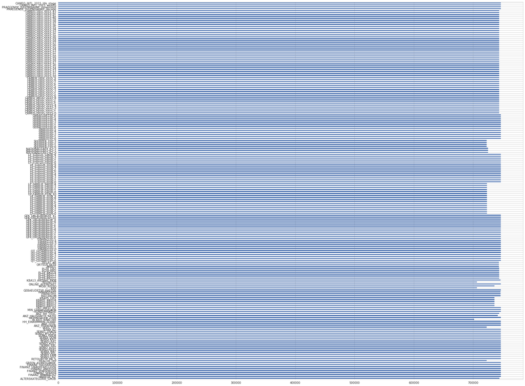

```python
# Inspecting missing data of each column first

def plot_count(df):
    df.count().plot(kind='barh')
    fig = plt.gcf()
    fig.set_size_inches(30, 25)

plot_count(azdias_clean)
```

```python
# Inspect columns that still have missing values
df_count_after_dropna = azdias_clean.count()

num_rows = azdias_clean.shape[0]
col_withna = df_count_after_dropna[df_count_after_dropna < num_rows].index.tolist()
```

```python
len(col_withna)
```

```
105
```

```python
feat_info_hasna = feat_info[feat_info['attribute'].isin(col_withna)]
```

```python
feat_info_hasna
```

|  | attribute | information_level | type | missing_or_unknown |
| --- | --- | --- | --- | --- |
| 1 | ALTERSKATEGORIE_GROB | person | ordinal | [-1,0,9] |
| 14 | HEALTH_TYP | person | ordinal | [-1,0] |
| 41 | VERS_TYP | person | categorical | [-1] |
| 48 | W_KEIT_KIND_HH | household | ordinal | [-1,0] |
| 50 | ANZ_HAUSHALTE_AKTIV | building | numeric | [0] |
| 51 | ANZ_HH_TITEL | building | numeric | [] |
| 53 | KONSUMNAEHE | building | ordinal | [] |
| 60 | KBA05_ANTG1 | microcell_rr3 | ordinal | [-1] |
| 61 | KBA05_ANTG2 | microcell_rr3 | ordinal | [-1] |
| 62 | KBA05_ANTG3 | microcell_rr3 | ordinal | [-1] |
| 63 | KBA05_ANTG4 | microcell_rr3 | ordinal | [-1] |
| 65 | KBA05_GBZ | microcell_rr3 | ordinal | [-1,0] |
| 66 | BALLRAUM | postcode | ordinal | [-1] |
| 67 | EWDICHTE | postcode | ordinal | [-1] |
| 68 | INNENSTADT | postcode | ordinal | [-1] |
| 69 | GEBAEUDETYP_RASTER | region_rr1 | ordinal | [] |
| 70 | KKK | region_rr1 | ordinal | [-1,0] |
| 71 | MOBI_REGIO | region_rr1 | ordinal | [] |
| 73 | REGIOTYP | region_rr1 | ordinal | [-1,0] |
| 74 | KBA13_ANZAHL_PKW | macrocell_plz8 | numeric | [] |
| 75 | PLZ8_ANTG1 | macrocell_plz8 | ordinal | [-1] |
| 76 | PLZ8_ANTG2 | macrocell_plz8 | ordinal | [-1] |
| 77 | PLZ8_ANTG3 | macrocell_plz8 | ordinal | [-1] |
| 78 | PLZ8_ANTG4 | macrocell_plz8 | ordinal | [-1] |
| 80 | PLZ8_HHZ | macrocell_plz8 | ordinal | [-1] |
| 81 | PLZ8_GBZ | macrocell_plz8 | ordinal | [-1] |
| 82 | ARBEIT | community | ordinal | [-1,9] |
| 83 | ORTSGR_KLS9 | community | ordinal | [-1,0] |
| 84 | RELAT_AB | community | ordinal | [-1,9] |

```python
# Fill non-numeric columns with with 0 since we are going to use it to represent unknown value
col_numeric = feat_info.query('type == "numeric"')['attribute'].tolist()

all_columns_final = azdias_clean.columns
col_non_numeric = all_columns_final[~all_columns_final.isin(col_numeric)].tolist()

azdias_clean[col_non_numeric] = azdias_clean[col_non_numeric].fillna(0)
```

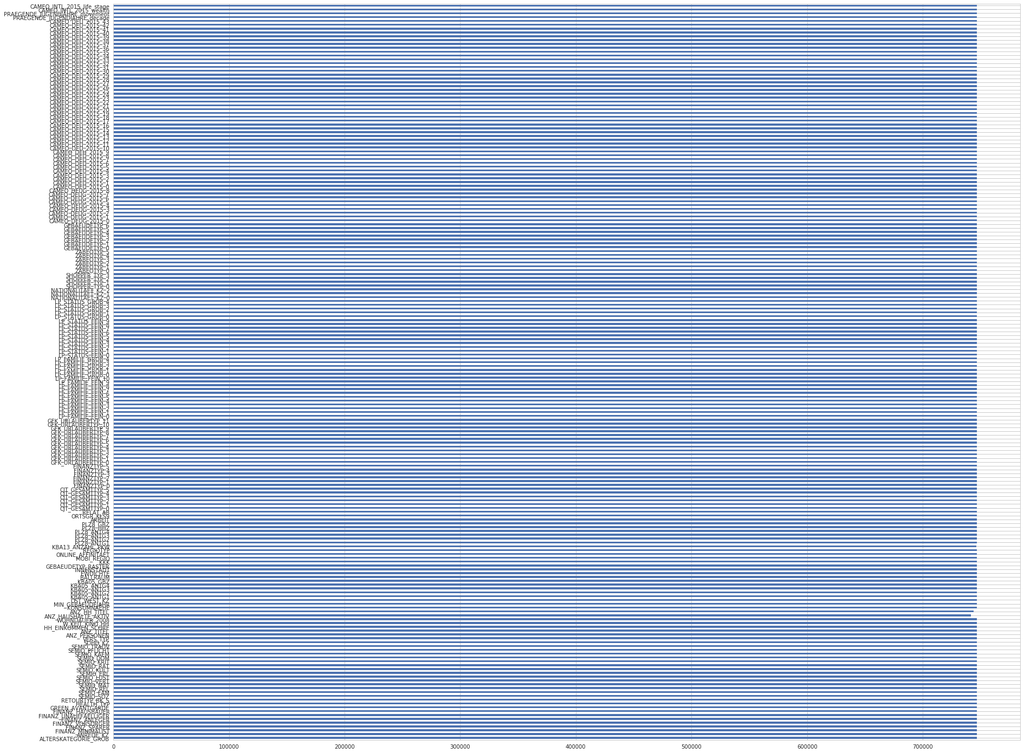

```python
# Plot count after handling all missing values

plot_count(azdias_clean)
```

```python
azdias_clean.describe()
```

|  | ALTERSKATEGORIE_GROB | ANREDE_KZ | FINANZ_MINIMALIST | FINANZ_SPARER | FINANZ_VORSORGER | FINANZ_ANLEGER | FINANZ_UNAUFFAELLIGER | FINANZ_HAUSBAUER | GREEN_AVANTGARDE | HEALTH_TYP | ... | CAMEO_DEU_2015_38 | CAMEO_DEU_2015_39 | CAMEO_DEU_2015_40 | CAMEO_DEU_2015_41 | CAMEO_DEU_2015_42 | CAMEO_DEU_2015_43 | PRAEGENDE_JUGENDJAHRE_decade | PRAEGENDE_JUGENDJAHRE_movement | CAMEO_INTL_2015_wealth | CAMEO_INTL_2015_life_stage |
| --- | --- | --- | --- | --- | --- | --- | --- | --- | --- | --- | --- | --- | --- | --- | --- | --- | --- | --- | --- | --- | --- |
| count | 747109.000000 | 747109.000000 | 747109.000000 | 747109.000000 | 747109.000000 | 747109.000000 | 747109.000000 | 747109.000000 | 747109.000000 | 747109.000000 | ... | 747109.000000 | 747109.000000 | 747109.000000 | 747109.000000 | 747109.000000 | 747109.000000 | 747109.000000 | 747109.000000 | 747109.000000 | 747109.000000 |
| mean | 2.787094 | 1.518915 | 3.060425 | 2.689336 | 3.450534 | 2.814572 | 2.596772 | 3.153737 | 0.223419 | 2.136174 | ... | 0.022837 | 0.026271 | 0.035418 | 0.031594 | 0.036983 | 0.007521 | 4.224366 | 1.201841 | 3.269771 | 2.862222 |
| std | 1.036419 | 0.499642 | 1.370273 | 1.481252 | 1.382074 | 1.466034 | 1.384991 | 1.386960 | 0.416537 | 0.840091 | ... | 0.149385 | 0.159939 | 0.184834 | 0.174916 | 0.188719 | 0.086397 | 1.574900 | 0.451948 | 1.478600 | 1.500456 |
| min | 0.000000 | 1.000000 | 1.000000 | 1.000000 | 1.000000 | 1.000000 | 1.000000 | 1.000000 | 0.000000 | 0.000000 | ... | 0.000000 | 0.000000 | 0.000000 | 0.000000 | 0.000000 | 0.000000 | 0.000000 | 0.000000 | 0.000000 | 0.000000 |
| 25% | 2.000000 | 1.000000 | 2.000000 | 1.000000 | 2.000000 | 1.000000 | 1.000000 | 2.000000 | 0.000000 | 2.000000 | ... | 0.000000 | 0.000000 | 0.000000 | 0.000000 | 0.000000 | 0.000000 | 3.000000 | 1.000000 | 2.000000 | 1.000000 |
| 50% | 3.000000 | 2.000000 | 3.000000 | 3.000000 | 4.000000 | 3.000000 | 2.000000 | 3.000000 | 0.000000 | 2.000000 | ... | 0.000000 | 0.000000 | 0.000000 | 0.000000 | 0.000000 | 0.000000 | 4.000000 | 1.000000 | 4.000000 | 3.000000 |
| 75% | 4.000000 | 2.000000 | 4.000000 | 4.000000 | 5.000000 | 4.000000 | 4.000000 | 4.000000 | 0.000000 | 3.000000 | ... | 0.000000 | 0.000000 | 0.000000 | 0.000000 | 0.000000 | 0.000000 | 6.000000 | 1.000000 | 5.000000 | 4.000000 |
| max | 4.000000 | 2.000000 | 5.000000 | 5.000000 | 5.000000 | 5.000000 | 5.000000 | 5.000000 | 1.000000 | 3.000000 | ... | 1.000000 | 1.000000 | 1.000000 | 1.000000 | 1.000000 | 1.000000 | 6.000000 | 2.000000 | 5.000000 | 5.000000 |

8 rows × 192 columns

### Step 1.3: Create a Cleaning Function

Even though you've finished cleaning up the general population demographics data, it's important to look ahead to the future and realize that you'll need to perform the same cleaning steps on the customer demographics data. In this substep, complete the function below to execute the main feature selection, encoding, and re-engineering steps you performed above. Then, when it comes to looking at the customer data in Step 3, you can just run this function on that DataFrame to get the trimmed dataset in a single step.

```python
def clean_data(df):
    """
    Perform feature trimming, re-encoding, and engineering for demographics
    data

    INPUT: Demographics DataFrame
    OUTPUT: Trimmed and cleaned demographics DataFrame
    """

    # --- Helper functions

    def parse_int(strVal):
        '''
        Parse string input value to the integer type.
        The original string will be return if the input value cannot be parsed to the integer type
        '''
        try:
            outNum = int(strVal)
        except ValueError:
            outNum = strVal

        return outNum


    def get_unique_values_for_columns(df_in, column_list):
        '''
        Get a number of unique values for the specified column_list
        '''
        unique_vals = {}

        for cur_column in column_list:
            cur_unique_vals = df_in[cur_column].dropna().unique()
            unique_vals[cur_column] = cur_unique_vals

        return unique_vals

    # ---

    # Load the feature info data first
    feat_info = pd.read_csv('AZDIAS_Feature_Summary.csv', sep=';')

    # Create a copy of the original data and use it in next steps
    df_clean = df.copy()

    # ----------------------------------------------------
    # Put in code here to execute all main cleaning steps:
    # convert missing value codes into NaNs, ...
    # ----------------------------------------------------

    print('* {}: Replace missing/values with np.NaN'.format(str(datetime.datetime.now())))

    # Loop through all rows in feat_info to get value(s) of missing/unknown values of each feature
    # Then, for each loop, replace missing/unknown values of a corresponding column with np.NaN
    for index, row in feat_info.iterrows():
        # Get a column name
        cur_attr = row['attribute']

        # Find value(s) of missing/unknow value of a corresponding column. Since this value is
        # stored as astring with a patter [num1 {,num2,...}], we will extract all missing values
        # by finding values inside [] which are split by a comma
        cur_missing = row['missing_or_unknown'].replace('[','').replace(']','').split(',')
        cur_list = []
        for cur_val in cur_missing:
            if cur_val:
                cur_list.append(parse_int(cur_val))

        # Replace missing value with NaN
        if cur_list:
            df_clean[cur_attr].replace(cur_list, np.NaN, inplace=True)

    # ----------------------------------------------------
    # remove selected columns and rows, ...
    # ----------------------------------------------------

    print('* {}: Remove selected columns'.format(str(datetime.datetime.now())))

    # --- Remove columns with a number of missing values greater than a threshold of the outlier

    drop_columns = ['TITEL_KZ',
        'AGER_TYP',
        'KK_KUNDENTYP',
        'KBA05_BAUMAX',
        'GEBURTSJAHR',
        'ALTER_HH',
        'LP_LEBENSPHASE_FEIN',
        'LP_LEBENSPHASE_GROB',
        'WOHNLAGE',
        'PLZ8_BAUMAX'
    ]

    df_clean = df_clean.drop(drop_columns, axis=1)

    # ----------------------------------------------------
    # select, re-encode, and engineer column values.
    # ----------------------------------------------------

    # First, get a list of columns of type 'categorical' and 'mixed'
    info_cat_type = feat_info.query('type == "categorical"')
    info_mixed_type = feat_info.query('type == "mixed"')

    columns_cat = info_cat_type['attribute'].tolist()
    columns_mixed = info_mixed_type['attribute'].tolist()

    # Exclude dropped columns from the list
    columns_cat_final = [cur_column for cur_column in columns_cat if cur_column not in drop_columns]
    columns_mixed_final = [cur_column for cur_column in columns_mixed if cur_column not in drop_columns]

    # Get a list of unique values in the 'categorical' and 'mixed' columns
    cat_unique = get_unique_values_for_columns(df_clean, columns_cat_final)
    mixed_unique = get_unique_values_for_columns(df_clean, columns_mixed_final)

    # Find a set of columns for binary, binary that needs encoding,
    # and multi-level categoricals for the category data

    columns_cat_bin = []
    columns_cat_bin_dummy = []
    columns_cat_multi_levels = []

    for cur_column in cat_unique.keys():

        cur_unique_vals = cat_unique[cur_column]
        num_vals = len(cur_unique_vals)

        if num_vals == 2:

            if df_clean[cur_column].dtype == 'O':
                columns_cat_bin_dummy.append(cur_column)
            else:
                columns_cat_bin.append(cur_column)

        else:
            columns_cat_multi_levels.append(cur_column)

    # --- Binary columns
    # Since the 'OST_WEST_KZ' column is the only binary column that
    # does not use numerical values, create a dummy variable for the
    # 'OST_WEST_KZ' column.
    # Then, append it to the original dataframe.
    # Also, drop the original column since we don't need it anymore

    print('* {}: Engineer binary columns'.format(str(datetime.datetime.now())))

    # Since the 'OST_WEST_KZ' column is the only binary column that does not use numerical values,
    # we will encode the value 'O' with 1 and 'W' with 2, and encode NaN with 0

    df_clean['OST_WEST_KZ'] = df_clean['OST_WEST_KZ'].replace({'O': 1, 'W': 2})

    # Also, encode NaN as all zeros
    df_clean['OST_WEST_KZ'] = df_clean['OST_WEST_KZ'].fillna(0)

    # --- Multi-level categorical columns

    print('* {}: Engineer multi-level categorical columns'.format(str(datetime.datetime.now())))

    # Encode Multi-level categorical columns first

    # Create a new datafreame with the same index first
    index_data = df_clean.index.tolist()
    df_mul =  pd.DataFrame(index=index_data)

    for cur_column in columns_cat_multi_levels:

        df_temp = df_clean[cur_column].dropna()
        cur_index = df_temp.index.tolist()

        ohe = OneHotEncoder()

        if df_clean[cur_column].dtype == 'O':
            # If values in the column are string, we need to encode them
            # to numerical values first
            le = LabelEncoder()
            cur_data = le.fit_transform(df_temp)
        else:
            # If values in the column are already numerical values,
            # we need to reshape data first since the OneHotEncoder expects 2D data
            cur_data = df_temp.values

        X = ohe.fit_transform(cur_data.reshape(-1,1)).toarray()
        dfOneHot = pd.DataFrame(X,
                                columns = [cur_column + "_" + str(int(i)) for i in range(X.shape[1])],
                                index=cur_index)

        df_mul = pd.concat([df_mul , dfOneHot], axis=1)

    # Drop previous multi-level categorical columns.
    # Then, concatenate it to the original data
    df_clean = df_clean.drop(columns_cat_multi_levels, axis=1);
    df_clean = pd.concat([df_clean, df_mul], axis=1)

    # --- Mixed columns

    print('* {}: Engineer mixed columns'.format(str(datetime.datetime.now())))

    ## Engineer Mixed-Type Features

    # ----- PRAEGENDE_JUGENDJAHRE column

    # Investigate "PRAEGENDE_JUGENDJAHRE" and engineer two new variables.
    df_pj_decade = df_clean['PRAEGENDE_JUGENDJAHRE'].copy()
    df_pj_movement = df_clean['PRAEGENDE_JUGENDJAHRE'].copy()

    # ----- decade
    # Create a mapping for decade
    map_pj_decade = {
        1.: '40s',
        2.: '40s',
        3.: '50s',
        4.: '50s',
        5.: '60s',
        6.: '60s',
        7.: '60s',
        8.: '70s',
        9.: '70s',
        10.: '80s',
        11.: '80s',
        12.: '80s',
        13.: '80s',
        14.: '90s',
        15.: '90s'
    }

    # Replace numerica values with decade values using the map_pj_decade that just created
    df_pj_decade = df_pj_decade.replace(map_pj_decade)

    # Replace nan with a string value 'NaN'
    df_pj_decade = df_pj_decade.fillna('NaN')

    # Then, convert this pandas Series to a 'category' type
    df_pj_decade = df_pj_decade.astype('category', categories=['NaN', '40s', '50s', '60s', '70s', '80s', '90s'])

    # Encode values in the decade column
    df_pj_decade_codes = df_pj_decade.cat.codes

    # Create a new column 'PRAEGENDE_JUGENDJAHRE_decade' and assign the encoded value above
    # to this column
    df_clean['PRAEGENDE_JUGENDJAHRE_decade'] = df_pj_decade_codes


    # ----- movement
    # Create a mapping that will be use to identify the movement value first
    # (1.0 is mainstream , 2.0 is avantgarde)
    map_pj_movement = {
        1.: 1.,
        2.: 2.,
        3.: 1.,
        4.: 2.,
        5.: 1.,
        6.: 2.,
        7.: 2.,
        8.: 1.,
        9.: 2.,
        10.: 1.,
        11.: 2.,
        12.: 1.,
        13.: 2.,
        14.: 1.,
        15.: 2.
    }

    # Create a binary variable for movement and encode with the newly created map
    df_pj_movement = df_clean['PRAEGENDE_JUGENDJAHRE'].copy()
    df_pj_movement = df_pj_movement.replace(map_pj_movement)

    # Fill all missing values with 0
    df_pj_movement = df_pj_movement.fillna(0);

    df_clean['PRAEGENDE_JUGENDJAHRE_movement'] = df_pj_movement

    # Also, drop the original column since we don't need it anymore
    df_clean = df_clean.drop(['PRAEGENDE_JUGENDJAHRE'], axis=1)

    # ----- CAMEO_INTL_2015 column

    # Clean the "CAMEO_INTL_2015" column by breaking up the two-digit codes by their
    # 'tens'-place and 'ones'-place digits into two new ordinal variables

    df_ci_wealth =  df_clean['CAMEO_INTL_2015'].str[:1].astype('float')
    df_ci_life_stage =  df_clean['CAMEO_INTL_2015'].str[1:].astype('float')

    # Replace nan with 0

    df_ci_wealth = df_ci_wealth.fillna(0)
    df_ci_life_stage = df_ci_life_stage.fillna(0)

    # Create new columns

    df_clean['CAMEO_INTL_2015_wealth'] = df_ci_wealth
    df_clean['CAMEO_INTL_2015_life_stage'] = df_ci_life_stage

    # Also, drop the original column since we don't need it anymore
    df_clean = df_clean.drop(['CAMEO_INTL_2015'], axis=1)

    # ----------------------------------------------------
    # Additional cleaning steps
    # ----------------------------------------------------

    print('* {}: Additional cleaning steps'.format(str(datetime.datetime.now())))

    # Fill the rest of missing values with 0 if it is not numeric
    col_numeric = feat_info.query('type == "numeric"')['attribute'].tolist()

    all_columns_final = df_clean.columns
    col_non_numeric = all_columns_final[~all_columns_final.isin(col_numeric)].tolist()

    df_clean[col_non_numeric] = df_clean[col_non_numeric].fillna(0)

    # ----------------------------------------------------
    # Return the cleaned dataframe.

    return df_clean
```

## Step 2: Feature Transformation

### Step 2.1: Apply Feature Scaling

Before we apply dimensionality reduction techniques to the data, we need to perform feature scaling so that the principal component vectors are not influenced by the natural differences in scale for features. Starting from this part of the project, you'll want to keep an eye on the [API reference page for sklearn](http://scikit-learn.org/stable/modules/classes.html) to help you navigate to all of the classes and functions that you'll need. In this substep, you'll need to check the following:

- sklearn requires that data not have missing values in order for its estimators to work properly. So, before applying the scaler to your data, make sure that you've cleaned the DataFrame of the remaining missing values. This can be as simple as just removing all data points with missing data, or applying an [Imputer](http://scikit-learn.org/stable/modules/generated/sklearn.preprocessing.Imputer.html) to replace all missing values. You might also try a more complicated procedure where you temporarily remove missing values in order to compute the scaling parameters before re-introducing those missing values and applying imputation. Think about how much missing data you have and what possible effects each approach might have on your analysis, and justify your decision in the discussion section below.
- For the actual scaling function, a [StandardScaler](http://scikit-learn.org/stable/modules/generated/sklearn.preprocessing.StandardScaler.html) instance is suggested, scaling each feature to mean 0 and standard deviation 1.
- For these classes, you can make use of the `.fit_transform()` method to both fit a procedure to the data as well as apply the transformation to the data at the same time. Don't forget to keep the fit sklearn objects handy, since you'll be applying them to the customer demographics data towards the end of the project.

#### Handle missing data

```python
# If you've not yet cleaned the dataset of all NaN values, then investigate and
# do that now.
```

Find columns with missing values and see distribution of data of those columns

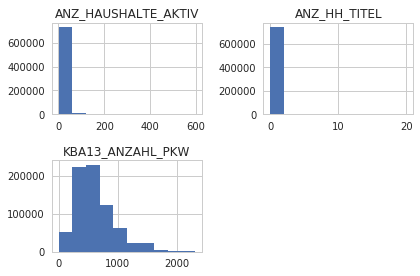

```python
# Find columns with missing values
num_records = azdias_clean.shape[0]
df_count = azdias_clean.count()
df_col_withna = df_count[df_count < num_records]
columns_withna = df_col_withna.index.tolist()

# Create histogram for columns with missing value
azdias_clean[columns_withna].hist();
plt.tight_layout()
```

```python
# Get a list of columns with missing values
columns_withna
```

```
['ANZ_HAUSHALTE_AKTIV', 'ANZ_HH_TITEL', 'KBA13_ANZAHL_PKW']
```

As we can see above, the remaining features with missing data are all numeric-type and their distributions are right-skew. Hence, we will create an Imputer with the median strategy to fill those missing data.

In order to ease process in the next steps of the analysis, we will create a new imputer object for all numerical-type feature and fit with the training dataset so that we can use it in the next part of the analysis.

```python
# Create an imputer for each numeric-type columns
# so that we can use it in the next step of the analysis

columns_numeric = feat_info[feat_info['attribute'].isin(azdias_clean.columns.tolist())].query('type == "numeric"')['attribute']

dict_imputers = {}

for cur_col in columns_numeric:

    imp = Imputer(strategy='median', axis=0)
    X_imp = imp.fit_transform(azdias_clean[cur_col].values.reshape(-1,1)).tolist()

    azdias_clean[cur_col] = np.ravel(X_imp).tolist()

    # Store the current imputer in dict_imputers
    dict_imputers[cur_col] = imp
```

#### Scale data

```python
def scale_values(df, scalers=None):
    '''
    Scale the input dataframe.
    '''
    all_columns = df.columns.tolist()

    # Create a copy of azdias_clean to store scaled data
    df_scale = df.copy()
    out_scalers = {}

    for cur_col in keep_awake(all_columns):
#         print('{}: Scaling "{}"'.format(str(datetime.datetime.now()), cur_col))

        if not scalers:
            # If scalers are not specified, create a new default StandardScaler
            scaler = StandardScaler()
            df_scale[cur_col] = scaler.fit_transform(df_scale[cur_col].values.reshape(-1, 1))

        else:
            # Otherwise, use the specified scaler for this column
            scaler = scalers[cur_col]
            df_scale[cur_col] = scaler.transform(df_scale[cur_col].values.reshape(-1, 1))


        # Add the current scaler to the dictionary
        out_scalers[cur_col] = scaler

    # Re-order columns
    df_scale = df_scale.reindex_axis(sorted(df_scale.columns), axis=1)

    return df_scale, out_scalers
```

```python
azdias_clean_scale, azdias_clean_scalers = scale_values(azdias_clean)
```

Inspect the scaled data

```python
azdias_clean_scale.sample(5)
```

|  | ALTERSKATEGORIE_GROB | ANREDE_KZ | ANZ_HAUSHALTE_AKTIV | ANZ_HH_TITEL | ANZ_PERSONEN | ANZ_TITEL | ARBEIT | BALLRAUM | CAMEO_DEUG_2015_0 | CAMEO_DEUG_2015_1 | ... | SOHO_KZ | VERS_TYP | WOHNDAUER_2008 | W_KEIT_KIND_HH | ZABEOTYP_0 | ZABEOTYP_1 | ZABEOTYP_2 | ZABEOTYP_3 | ZABEOTYP_4 | ZABEOTYP_5 |
| --- | --- | --- | --- | --- | --- | --- | --- | --- | --- | --- | --- | --- | --- | --- | --- | --- | --- | --- | --- | --- | --- |
| 73006 | 1.170287 | -1.038573 | 0.356753 | -0.127668 | -0.637621 | -0.060769 | 0.821310 | -1.434794 | -0.220008 | -0.339808 | ... | -0.091952 | -0.852849 | -2.089551 | 1.039069 | -0.425893 | -0.1949 | 1.349655 | -0.594610 | -0.340236 | -0.315438 |
| 414020 | 1.170287 | 0.962859 | -0.282806 | -0.127668 | -0.637621 | -0.060769 | -2.125597 | 0.392616 | -0.220008 | -0.339808 | ... | -0.091952 | 0.929638 | -1.561373 | -0.473017 | -0.425893 | -0.1949 | 1.349655 | -0.594610 | -0.340236 | -0.315438 |
| 322054 | -1.724298 | 0.962859 | 0.228842 | -0.127668 | 1.082603 | -0.060769 | -0.160993 | -0.521089 | -0.220008 | -0.339808 | ... | -0.091952 | 0.929638 | 0.551338 | -0.977045 | -0.425893 | -0.1949 | -0.740930 | 1.681774 | -0.340236 | -0.315438 |
| 859812 | 0.205425 | 0.962859 | -0.282806 | -0.127668 | -0.637621 | -0.060769 | -1.143295 | -0.977941 | -0.220008 | 2.942840 | ... | -0.091952 | 0.929638 | 0.551338 | 1.039069 | -0.425893 | -0.1949 | 1.349655 | -0.594610 | -0.340236 | -0.315438 |
| 589241 | -0.759437 | -1.038573 | -0.346761 | -0.127668 | -0.637621 | -0.060769 | -0.160993 | 1.306322 | -0.220008 | 2.942840 | ... | -0.091952 | -0.852849 | -2.089551 | 0.031012 | -0.425893 | -0.1949 | -0.740930 | 1.681774 | -0.340236 | -0.315438 |

5 rows × 192 columns

```python
azdias_clean_scale.describe()
```

|  | ALTERSKATEGORIE_GROB | ANREDE_KZ | ANZ_HAUSHALTE_AKTIV | ANZ_HH_TITEL | ANZ_PERSONEN | ANZ_TITEL | ARBEIT | BALLRAUM | CAMEO_DEUG_2015_0 | CAMEO_DEUG_2015_1 | ... | SOHO_KZ | VERS_TYP | WOHNDAUER_2008 | W_KEIT_KIND_HH | ZABEOTYP_0 | ZABEOTYP_1 | ZABEOTYP_2 | ZABEOTYP_3 | ZABEOTYP_4 | ZABEOTYP_5 |
| --- | --- | --- | --- | --- | --- | --- | --- | --- | --- | --- | --- | --- | --- | --- | --- | --- | --- | --- | --- | --- | --- |
| count | 7.471090e+05 | 7.471090e+05 | 7.471090e+05 | 7.471090e+05 | 7.471090e+05 | 7.471090e+05 | 7.471090e+05 | 7.471090e+05 | 7.471090e+05 | 7.471090e+05 | ... | 7.471090e+05 | 7.471090e+05 | 7.471090e+05 | 7.471090e+05 | 7.471090e+05 | 7.471090e+05 | 7.471090e+05 | 7.471090e+05 | 7.471090e+05 | 7.471090e+05 |
| mean | -1.738246e-16 | -3.487999e-18 | -2.177919e-18 | 4.094297e-17 | 2.963491e-17 | -3.175577e-17 | 1.988373e-16 | 1.616796e-16 | 1.110834e-17 | 6.206594e-17 | ... | 4.181319e-17 | -1.622597e-16 | -2.159659e-16 | -5.931025e-17 | -6.588918e-17 | 1.052891e-16 | -3.922156e-17 | -8.174329e-17 | 9.681753e-18 | 3.036723e-17 |
| std | 1.000001e+00 | 1.000001e+00 | 1.000001e+00 | 1.000001e+00 | 1.000001e+00 | 1.000001e+00 | 1.000001e+00 | 1.000001e+00 | 1.000001e+00 | 1.000001e+00 | ... | 1.000001e+00 | 1.000001e+00 | 1.000001e+00 | 1.000001e+00 | 1.000001e+00 | 1.000001e+00 | 1.000001e+00 | 1.000001e+00 | 1.000001e+00 | 1.000001e+00 |
| min | -2.689160e+00 | -1.038573e+00 | -4.746732e-01 | -1.276685e-01 | -1.497732e+00 | -6.076933e-02 | -3.107900e+00 | -1.891647e+00 | -2.200076e-01 | -3.398078e-01 | ... | -9.195222e-02 | -2.635336e+00 | -3.674084e+00 | -1.985102e+00 | -4.258931e-01 | -1.948996e-01 | -7.409301e-01 | -5.946102e-01 | -3.402365e-01 | -3.154384e-01 |
| 25% | -7.594368e-01 | -1.038573e+00 | -4.107173e-01 | -1.276685e-01 | -6.376206e-01 | -6.076933e-02 | -1.609926e-01 | -9.779414e-01 | -2.200076e-01 | -3.398078e-01 | ... | -9.195222e-02 | -8.528491e-01 | 2.316008e-02 | -9.770450e-01 | -4.258931e-01 | -1.948996e-01 | -7.409301e-01 | -5.946102e-01 | -3.402365e-01 | -3.154384e-01 |
| 50% | 2.054249e-01 | 9.628594e-01 | -2.828056e-01 | -1.276685e-01 | -6.376206e-01 | -6.076933e-02 | -1.609926e-01 | 3.926164e-01 | -2.200076e-01 | -3.398078e-01 | ... | -9.195222e-02 | 9.296376e-01 | 5.513378e-01 | 3.101177e-02 | -4.258931e-01 | -1.948996e-01 | -7.409301e-01 | -5.946102e-01 | -3.402365e-01 | -3.154384e-01 |
| 75% | 1.170287e+00 | 9.628594e-01 | 1.009298e-01 | -1.276685e-01 | 2.224913e-01 | -6.076933e-02 | 8.213099e-01 | 8.494690e-01 | -2.200076e-01 | -3.398078e-01 | ... | -9.195222e-02 | 9.296376e-01 | 5.513378e-01 | 1.039069e+00 | -4.258931e-01 | -1.948996e-01 | 1.349655e+00 | 1.681774e+00 | -3.402365e-01 | -3.154384e-01 |
| max | 1.170287e+00 | 9.628594e-01 | 3.751512e+01 | 6.311898e+01 | 3.720730e+01 | 5.852157e+01 | 1.803612e+00 | 1.306322e+00 | 4.545297e+00 | 2.942840e+00 | ... | 1.087521e+01 | 9.296376e-01 | 5.513378e-01 | 1.039069e+00 | 2.348007e+00 | 5.130847e+00 | 1.349655e+00 | 1.681774e+00 | 2.939132e+00 | 3.170191e+00 |

8 rows × 192 columns

### Discussion 2.1: Apply Feature Scaling

Handling missing data:

- All columns that have missing values are columns with numerical values and they need to be imputed before apply feature scaling.
- For the 'ANZ_HAUSHALTE_AKTIV' and 'KBA13_ANZAHL_PKW' columns, the distribution of those columns are right-skew, the median value was used to impute the missing values to keep the shape of the distribution.
- For the 'ANZ_HH_TITEL' column, since most values are 0, 0 was used to imputed the missing values.

Scaling data

- After filling all missing data, the StandardScaler with default settings (mean = 0., variance=1) is used to scale all features.

### Step 2.2: Perform Dimensionality Reduction

On your scaled data, you are now ready to apply dimensionality reduction techniques.

- Use sklearn's [PCA](http://scikit-learn.org/stable/modules/generated/sklearn.decomposition.PCA.html) class to apply principal component analysis on the data, thus finding the vectors of maximal variance in the data. To start, you should not set any parameters (so all components are computed) or set a number of components that is at least half the number of features (so there's enough features to see the general trend in variability).
- Check out the ratio of variance explained by each principal component as well as the cumulative variance explained. Try plotting the cumulative or sequential values using matplotlib's [`plot()`](https://matplotlib.org/api/_as_gen/matplotlib.pyplot.plot.html) function. Based on what you find, select a value for the number of transformed features you'll retain for the clustering part of the project.
- Once you've made a choice for the number of components to keep, make sure you re-fit a PCA instance to perform the decided-on transformation.

```python
# Apply PCA to the data.
```

First, we create a scree plot with the default PCA setting (n_components=number_of_features) so that we can use it to determine a final n_components

```python
pca_default = PCA()

print('Start: {}'.format(str(datetime.datetime.now())))
X_pca_default = pca_default.fit_transform(azdias_clean_scale)
print('End: {}'.format(str(datetime.datetime.now())))
```

```
Start: 2018-12-11 12:39:10.429408
End: 2018-12-11 12:40:23.017269
```

```python
# Use a scree_plot function that was used in the mini-project
def scree_plot(pca, max_x_axis=None, show_annotation=False):
    '''
    Creates a scree plot associated with the principal components

    INPUT: pca - the result of instantian of PCA in scikit learn

    OUTPUT:
            None
    '''
    if (max_x_axis):
        num_components = max_x_axis
    else:
        num_components = len(pca.explained_variance_ratio_)

    ind = np.arange(num_components)
    vals = pca.explained_variance_ratio_[:num_components]

    plt.figure(figsize=(12, 8))
    ax = plt.subplot(111)
    cumvals = np.cumsum(vals)
    ax.bar(ind, vals)
    ax.plot(ind, cumvals)
    if (show_annotation):
        for i in range(num_components):
            ax.annotate(r"%s%%" % ((str(vals[i]*100)[:4])), (ind[i]+0.2, vals[i]), va="bottom", ha="center", fontsize=8)

    ax.xaxis.set_tick_params(width=0)
    ax.yaxis.set_tick_params(width=2, length=12)

    ax.set_xlabel("Principal Component")
    ax.set_ylabel("Variance Explained (%)")
    plt.title('Explained Variance Per Principal Component')

    plt.tight_layout()
```

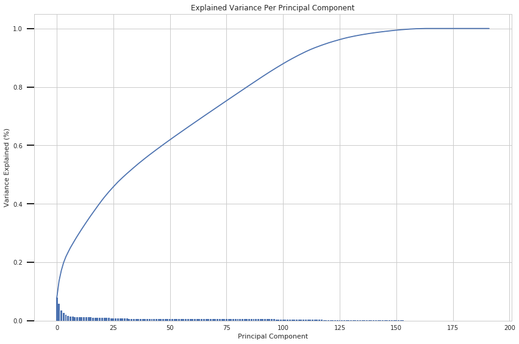

```python
scree_plot(pca_default)
```

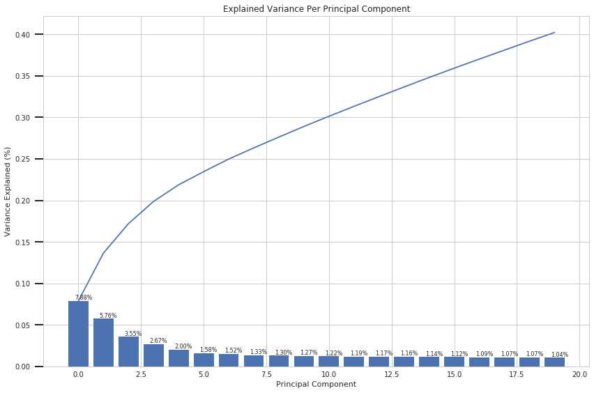

```python
# Investigate the variance accounted for by each principal component.

scree_plot(pca_default, max_x_axis=20, show_annotation=True)
```

```python
# Re-apply PCA to the data while selecting for number of components to retain.

# Use n_components=125 since it can explain more than 80% of the variability in the original data.
n_components_final = 125
pca_final = PCA(n_components=n_components_final)

print('Start: {}'.format(str(datetime.datetime.now())))
X_pca_final = pca_final.fit_transform(azdias_clean_scale)
print('End: {}'.format(str(datetime.datetime.now())))
```

```
Start: 2018-12-11 12:40:28.454210
End: 2018-12-11 12:42:53.357941
```

```python
vals = pca_final.explained_variance_ratio_

print("Using {} components, we can explain {:.2f}% of the variability in the original data.".format(n_components_final, vals.sum()*100))
```

```
Using 125 components, we can explain 95.97% of the variability in the original data.
```

### Discussion 2.2: Perform Dimensionality Reduction

Based on the scree plot, 125 principal components is selected since it is where the plot starts to turn sharply and it can explain over 95% of the variability in the original data.

### Step 2.3: Interpret Principal Components

Now that we have our transformed principal components, it's a nice idea to check out the weight of each variable on the first few components to see if they can be interpreted in some fashion.

As a reminder, each principal component is a unit vector that points in the direction of highest variance (after accounting for the variance captured by earlier principal components). The further a weight is from zero, the more the principal component is in the direction of the corresponding feature. If two features have large weights of the same sign (both positive or both negative), then increases in one tend expect to be associated with increases in the other. To contrast, features with different signs can be expected to show a negative correlation: increases in one variable should result in a decrease in the other.

- To investigate the features, you should map each weight to their corresponding feature name, then sort the features according to weight. The most interesting features for each principal component, then, will be those at the beginning and end of the sorted list. Use the data dictionary document to help you understand these most prominent features, their relationships, and what a positive or negative value on the principal component might indicate.
- You should investigate and interpret feature associations from the first three principal components in this substep. To help facilitate this, you should write a function that you can call at any time to print the sorted list of feature weights, for the *i*-th principal component. This might come in handy in the next step of the project, when you interpret the tendencies of the discovered clusters.

```python
# Map weights for the first principal component to corresponding feature names
# and then print the linked values, sorted by weight.
# HINT: Try defining a function here or in a new cell that you can reuse in the
# other cells.
```

```python
def get_pca_feature_weights(full_dataset, pca, index_component=1):
    '''
    Get a feature weights map for the specified principle component index and
    also the explained variance
    '''

    index = index_component - 1

    # Get a feature weights map
    pca_components = pca.components_[index]
    feat_weights = pd.DataFrame(np.round(pca_components, 4), columns=['weight'], index = full_dataset.keys())
    feat_weights = feat_weights.sort_values(by=['weight'], ascending=False)

    # Explaied variance

    explained_variance = pca_final.explained_variance_ratio_[index]

    return feat_weights, explained_variance
```

```python
feat_weights_1, explained_variance_1 = get_pca_feature_weights(azdias_clean_scale, pca_final, index_component=1)
```

```python
feat_weights_1.head()
```

|  | weight |
| --- | --- |
| LP_STATUS_GROB_0 | 0.1968 |
| HH_EINKOMMEN_SCORE | 0.1871 |
| CAMEO_INTL_2015_wealth | 0.1855 |
| PLZ8_ANTG3 | 0.1821 |
| PLZ8_ANTG4 | 0.1766 |

```python
feat_weights_1.tail()
```

|  | weight |
| --- | --- |
| KBA05_GBZ | -0.1734 |
| PLZ8_ANTG1 | -0.1816 |
| KBA05_ANTG1 | -0.1909 |
| FINANZ_MINIMALIST | -0.1939 |
| MOBI_REGIO | -0.1980 |

```python
print('The amount of variability explained by the first component is {:.6f}'.format(explained_variance_1))
```

```
The amount of variability explained by the first component is 0.078802
```

```python
# Map weights for the second principal component to corresponding feature names
# and then print the linked values, sorted by weight.

feat_weights_2, explained_variance_2 = get_pca_feature_weights(azdias_clean_scale, pca_final, index_component=2)
```

```python
feat_weights_2.head()
```

|  | weight |
| --- | --- |
| ALTERSKATEGORIE_GROB | 0.2309 |
| FINANZ_VORSORGER | 0.2162 |
| ZABEOTYP_2 | 0.2023 |
| SEMIO_ERL | 0.1843 |
| SEMIO_LUST | 0.1635 |

```python
feat_weights_2.tail()
```

|  | weight |
| --- | --- |
| SEMIO_TRADV | -0.2093 |
| FINANZ_UNAUFFAELLIGER | -0.2125 |
| SEMIO_REL | -0.2165 |
| FINANZ_SPARER | -0.2241 |
| PRAEGENDE_JUGENDJAHRE_decade | -0.2266 |

```python
print('The amount of variability explained by the second component is {:.6f}'.format(explained_variance_2))
```

```
The amount of variability explained by the second component is 0.057683
```

```python
# Map weights for the third principal component to corresponding feature names
# and then print the linked values, sorted by weight.

feat_weights_3, explained_variance_3 = get_pca_feature_weights(azdias_clean_scale, pca_final, index_component=3)
```

```python
feat_weights_3.head()
```

|  | weight |
| --- | --- |
| SEMIO_VERT | 0.3216 |
| SEMIO_FAM | 0.2583 |
| SEMIO_SOZ | 0.2575 |
| SEMIO_KULT | 0.2465 |
| FINANZTYP_4 | 0.1371 |

```python
feat_weights_3.tail()
```

|  | weight |
| --- | --- |
| SEMIO_ERL | -0.2021 |
| SEMIO_KRIT | -0.2616 |
| SEMIO_DOM | -0.2823 |
| SEMIO_KAEM | -0.3149 |
| ANREDE_KZ | -0.3462 |

```python
print('The amount of variability explained by the third component is {:.6f}'.format(explained_variance_3))
```

```
The amount of variability explained by the third component is 0.035531
```

### Discussion 2.3: Interpret Principal Components

##### First component

The first component can explain around 0.08 of the variability in the original data

- The features with top positive weights are related to wealth (HH_EINKOMMEN_SCORE and CAMEO_INTL_2015) and a number of family houses in the PLZ8 macro-cell features. Where when a value of HH_EINKOMMEN_SCORE or CAMEO_INTL_2015 increased which means that the household net income is decreased or the family gets poorer, we will likely see an increasein a number of family houses in the PLZ8 macro-cell.
- The features with top negative weights are related to movement pattern, Financial interest, and a number of family houses in the RR3 micro-cell features. When the movement pattern value and the financial interest value are increased (Less movement and lower financial interest), we will likely see an increase in a number of family houses in the RR3 micro-cell.
- When the family wealth is poorer, we will likey see higher movement pattern

##### Second component

The second component can explain around 0.06 of the variability in the original data.

##### Third component

The third component can explain around 0.03 of the variability in the original data.

## Step 3: Clustering

### Step 3.1: Apply Clustering to General Population

You've assessed and cleaned the demographics data, then scaled and transformed them. Now, it's time to see how the data clusters in the principal components space. In this substep, you will apply k-means clustering to the dataset and use the average within-cluster distances from each point to their assigned cluster's centroid to decide on a number of clusters to keep.

- Use sklearn's KMeans class to perform k-means clustering on the PCA-transformed data.
- Then, compute the average difference from each point to its assigned cluster's center. **Hint**: The KMeans object's `.score()` method might be useful here, but note that in sklearn, scores tend to be defined so that larger is better. Try applying it to a small, toy dataset, or use an internet search to help your understanding.
- Perform the above two steps for a number of different cluster counts. You can then see how the average distance decreases with an increasing number of clusters. However, each additional cluster provides a smaller net benefit. Use this fact to select a final number of clusters in which to group the data. **Warning**: because of the large size of the dataset, it can take a long time for the algorithm to resolve. The more clusters to fit, the longer the algorithm will take. You should test for cluster counts through at least 10 clusters to get the full picture, but you shouldn't need to test for a number of clusters above about 30.
- Once you've selected a final number of clusters to use, re-fit a KMeans instance to perform the clustering operation. Make sure that you also obtain the cluster assignments for the general demographics data, since you'll be using them in the final Step 3.3.

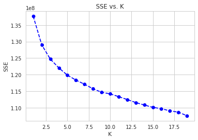

```python
# Investigate the change in within-cluster distance across number of clusters.
# HINT: Use matplotlib's plot function to visualize this relationship.

# I am showing an image of the kmeans score plot here instead of creating a new one
# because it takes a long time to complete it.
# Please see the commented code chunks below for how this plot is generated

Image("KMeansScore.png")
```

```python
# def get_kmeans_score(data, center):
#     '''
#     Fit a KMeans model with the specified number of clusters and return a score
#     '''

#     print('Start: {}'.format(str(datetime.datetime.now())))

#     model = KMeans(n_clusters=center).fit(data)
#     score = model.score(data)

#     print('End: {}'.format(str(datetime.datetime.now())))

#     return np.abs(score)

# scores = []
# centers = list(range(1,20))

# with active_session():

#     # Over a number of different cluster counts...

#     for cur_center in keep_awake(centers):
#         print('**** n_clusters={}'.format(cur_center))

#         # run k-means clustering on the data and...
#         # compute the average within-cluster distances.
#         cur_score = get_kmeans_score(X_pca_final, cur_center)
#         print('cur_score: {}'.format(cur_score))
#         scores.append(cur_score)
```

```python
# plt.plot(centers, scores, linestyle='--', marker='o', color='b');
# plt.xlabel('K');
# plt.ylabel('SSE');
# plt.title('SSE vs. K');
```

```python
# Re-fit the k-means model with the selected number of clusters and obtain
# cluster predictions for the general population demographics data.

# From the plot above, we will use n_clusters=15 to create a model
n_clusters = 15
```

```python
print('Start: {}'.format(str(datetime.datetime.now())))
model_K = KMeans(n_clusters=n_clusters).fit(X_pca_final)
print('End: {}'.format(str(datetime.datetime.now())))
```

```
Start: 2018-12-11 12:42:56.127299
End: 2018-12-11 12:49:54.646945
```

Next, invoke the predict method with the same data and we will use this data in the last step of this project

```python
predict_general = model_K.predict(X_pca_final)
```

Try visualize clustering in two dimensions by following the suggestion in the review feedback

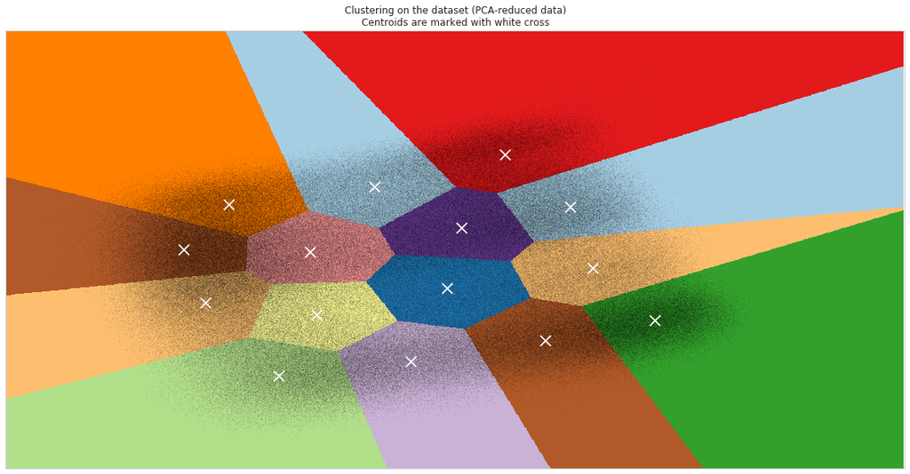

```python
reduced_data = PCA(n_components=2).fit_transform(azdias_clean_scale)


best_k = 15
clusters = KMeans(n_clusters=best_k, random_state=100).fit(reduced_data)


x_min, x_max = reduced_data[:, 0].min() - 1, reduced_data[:, 0].max() + 1
y_min, y_max = reduced_data[:, 1].min() - 1, reduced_data[:, 1].max() + 1
hx = (x_max-x_min)/1000.
hy = (y_max-y_min)/1000.
xx, yy = np.meshgrid(np.arange(x_min, x_max, hx), np.arange(y_min, y_max, hy))


Z = clusters.predict(np.c_[xx.ravel(), yy.ravel()])
centroids = clusters.cluster_centers_

def PCA_plot(Z, centroids):
    Z = Z.reshape(xx.shape)
    plt.figure(1, figsize=(20, 10))
    plt.clf()
    plt.imshow(Z, interpolation='nearest',
               extent=(xx.min(), xx.max(), yy.min(), yy.max()),
               cmap=plt.cm.Paired,
               aspect='auto', origin='lower')

    plt.plot(reduced_data[:, 0], reduced_data[:, 1], 'k.', markersize=2, alpha=0.1)
    plt.scatter(centroids[:, 0], centroids[:, 1],
                marker='x', s=169, linewidths=3,
                color='w', zorder=10)
    plt.title('Clustering on the dataset (PCA-reduced data)\n'
              'Centroids are marked with white cross')
    plt.xlim(x_min, x_max)
    plt.ylim(y_min, y_max)
    plt.xticks(())
    plt.yticks(())
    plt.show()

PCA_plot(Z, centroids)
```

### Step 3.2: Apply All Steps to the Customer Data

Now that you have clusters and cluster centers for the general population, it's time to see how the customer data maps on to those clusters. Take care to not confuse this for re-fitting all of the models to the customer data. Instead, you're going to use the fits from the general population to clean, transform, and cluster the customer data. In the last step of the project, you will interpret how the general population fits apply to the customer data.

- Don't forget when loading in the customers data, that it is semicolon (`;`) delimited.
- Apply the same feature wrangling, selection, and engineering steps to the customer demographics using the `clean_data()` function you created earlier. (You can assume that the customer demographics data has similar meaning behind missing data patterns as the general demographics data.)
- Use the sklearn objects from the general demographics data, and apply their transformations to the customers data. That is, you should not be using a `.fit()` or `.fit_transform()` method to re-fit the old objects, nor should you be creating new sklearn objects! Carry the data through the feature scaling, PCA, and clustering steps, obtaining cluster assignments for all of the data in the customer demographics data.

```python
# Load in the customer demographics data.
customers = pd.read_csv('Udacity_CUSTOMERS_Subset.csv', sep=';')
```

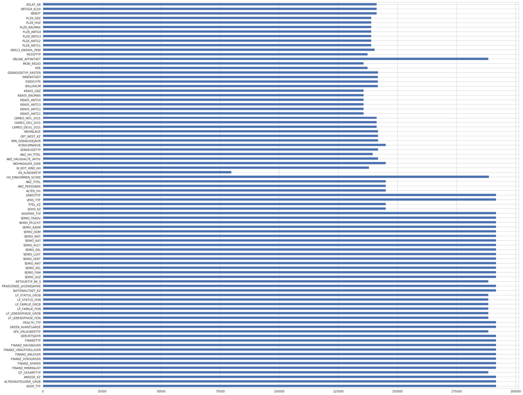

```python
# Inspect a number of data of each feature
plot_count(customers)
```

```python
# Apply preprocessing, feature transformation, and clustering from the general
# demographics onto the customer data, obtaining cluster predictions for the
# customer demographics data.

# Clean data first
customers_clean = clean_data(customers)
```

```
* 2018-12-11 12:53:48.621338: Replace missing/values with np.NaN
* 2018-12-11 12:53:49.239982: Remove selected columns
* 2018-12-11 12:53:49.923048: Engineer binary columns
* 2018-12-11 12:53:50.010890: Engineer multi-level categorical columns
* 2018-12-11 12:53:55.102884: Engineer mixed columns
* 2018-12-11 12:53:56.984964: Additional cleaning steps
```

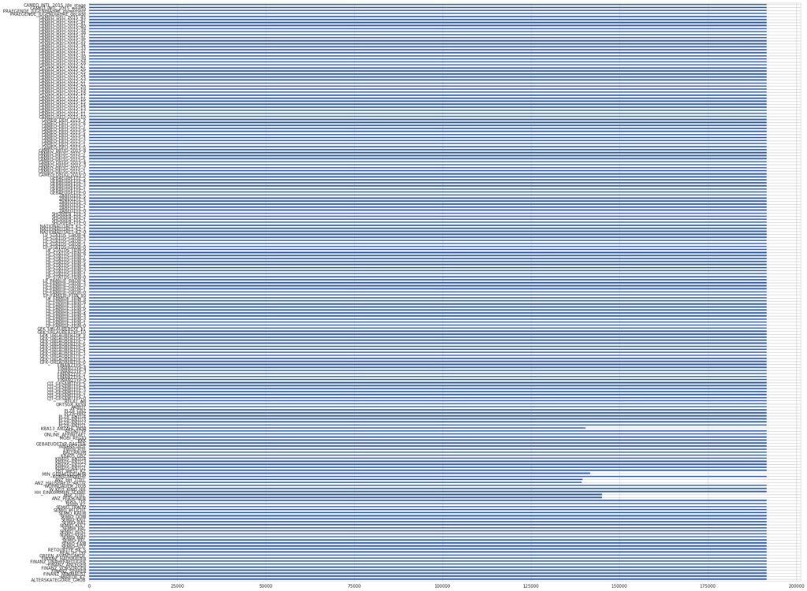

```python
# Inspect a number of data again after cleaning the data
plot_count(customers_clean)
```

```python
# Find columns with missing values
num_records = customers_clean.shape[0]
df_count = customers_clean.count()
df_col_withna = df_count[df_count < num_records]
columns_withna = df_col_withna.index.tolist()

print(columns_withna)
```

```
['ANZ_PERSONEN', 'ANZ_TITEL', 'ANZ_HAUSHALTE_AKTIV', 'ANZ_HH_TITEL', 'MIN_GEBAEUDEJAHR', 'KBA13_ANZAHL_PKW']
```

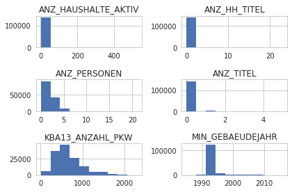

```python
# Create histogram for columns with missing value
customers_clean[columns_withna].hist();
plt.tight_layout()
```

We will use the Imputer objects that were created with the training dataset to fill the missing values in the customer data

```python
for cur_col in columns_withna:
    # Get an Imputer object for the current feature
    cur_imp = dict_imputers[cur_col]

    # Transform value of the current feature and assign it back
    cur_X = cur_imp.transform(customers_clean[cur_col].values.reshape(-1,1)).tolist()
    customers_clean[cur_col] = np.ravel(cur_X).tolist()
```

Let's take a look at the columns that just got imputed again

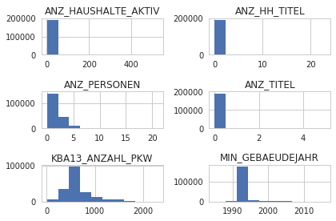

```python
customers_clean[columns_withna].hist();
plt.tight_layout()
```

Let's take a look at a number of data of each feature again after the imputation

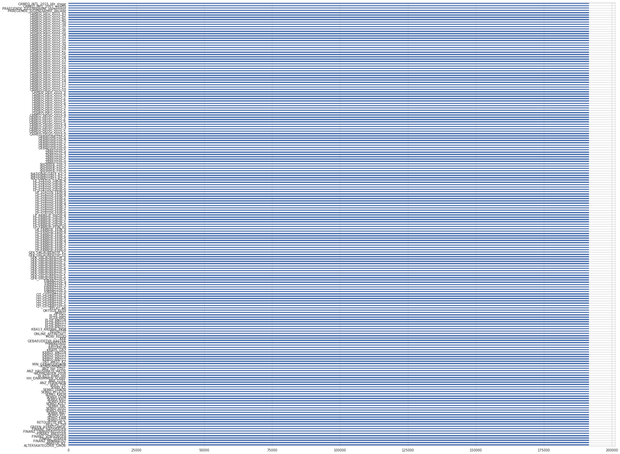

```python
plot_count(customers_clean)
```

The clean customer data does not contain the 'GEBAEUDETYP_6' (The 'GEBAEUDETYP' column of the original customer data does not contain 6. Hence, we need to manually add it.

```python
# Find missing columns in the customer data
list(set(azdias_clean.columns.tolist()) - set(customers_clean.columns.tolist()))
```

```
['GEBAEUDETYP_6']
```

```python
# We need to manually add this column since it is not present in the customer data
customers_clean['GEBAEUDETYP_6'] = 0.
```

Then, perform the feature scaling using the scalers that were fit with the original data

```python
# Use the scalers that were fit with the training data to scale the customers data
customers_scale, customers_scalers = scale_values(customers_clean, scalers=azdias_clean_scalers)
```

Transform the scaled customer data with the PCA object that was fit with the original data

```python
print('Start: {}'.format(str(datetime.datetime.now())))
X_customers_pca_final = pca_final.transform(customers_scale)
print('End: {}'.format(str(datetime.datetime.now())))
```

```
Start: 2018-12-11 13:13:18.408092
End: 2018-12-11 13:13:19.259269
```

Then, predict the pca's customer data with the KMeans model that was fit with the original data

```python
predict_customers = model_K.predict(X_customers_pca_final)
```

### Step 3.3: Compare Customer Data to Demographics Data

At this point, you have clustered data based on demographics of the general population of Germany, and seen how the customer data for a mail-order sales company maps onto those demographic clusters. In this final substep, you will compare the two cluster distributions to see where the strongest customer base for the company is.

Consider the proportion of persons in each cluster for the general population, and the proportions for the customers. If we think the company's customer base to be universal, then the cluster assignment proportions should be fairly similar between the two. If there are only particular segments of the population that are interested in the company's products, then we should see a mismatch from one to the other. If there is a higher proportion of persons in a cluster for the customer data compared to the general population (e.g. 5% of persons are assigned to a cluster for the general population, but 15% of the customer data is closest to that cluster's centroid) then that suggests the people in that cluster to be a target audience for the company. On the other hand, the proportion of the data in a cluster being larger in the general population than the customer data (e.g. only 2% of customers closest to a population centroid that captures 6% of the data) suggests that group of persons to be outside of the target demographics.

Take a look at the following points in this step:

- Compute the proportion of data points in each cluster for the general population and the customer data. Visualizations will be useful here: both for the individual dataset proportions, but also to visualize the ratios in cluster representation between groups. Seaborn's [`countplot()`](https://seaborn.pydata.org/generated/seaborn.countplot.html) or [`barplot()`](https://seaborn.pydata.org/generated/seaborn.barplot.html) function could be handy.
  - Recall the analysis you performed in step 1.1.3 of the project, where you separated out certain data points from the dataset if they had more than a specified threshold of missing values. If you found that this group was qualitatively different from the main bulk of the data, you should treat this as an additional data cluster in this analysis. Make sure that you account for the number of data points in this subset, for both the general population and customer datasets, when making your computations!
- Which cluster or clusters are overrepresented in the customer dataset compared to the general population? Select at least one such cluster and infer what kind of people might be represented by that cluster. Use the principal component interpretations from step 2.3 or look at additional components to help you make this inference. Alternatively, you can use the `.inverse_transform()` method of the PCA and StandardScaler objects to transform centroids back to the original data space and interpret the retrieved values directly.
- Perform a similar investigation for the underrepresented clusters. Which cluster or clusters are underrepresented in the customer dataset compared to the general population, and what kinds of people are typified by these clusters?

```python
# Compare the proportion of data in each cluster for the customer data to the
# proportion of data in each cluster for the general population.

# Create a new dataframe for predictions of the customer and general data
df_p_customers = pd.DataFrame(data=predict_customers, columns=['cluster_label'])
df_p_general = pd.DataFrame(data=predict_general, columns=['cluster_label'])
```

Then, find a proportion of each prediction label

```python
df_p_customers_propval = df_p_customers['cluster_label'].value_counts()/len(df_p_customers['cluster_label'])
df_p_general_propval = df_p_general['cluster_label'].value_counts()/len(df_p_general['cluster_label'])
```

Next, create a new data frame that merge the newly created dataframe for the proportion values

```python
# Create new data frames to ease the merge process
df_p_customers_prop_withinfo = pd.DataFrame(data = {
    'prop':df_p_customers_propval.tolist(),
    'cluster': df_p_customers_propval.index.tolist(),
    'type': 'customer'
})

df_p_general_prop_withinfo = pd.DataFrame(data = {
    'prop':df_p_general_propval.tolist(),
    'cluster': df_p_general_propval.index.tolist(),
    'type': 'general'
})

# Merge the above dataframes on the 'cluster' key
df_merge_prop = df_p_customers_prop_withinfo.merge(df_p_general_prop_withinfo, on=('cluster'), suffixes=('_customer', '_general'))

# Create a new column to store a difference between
# a propertion value of the customer data and the general data
df_merge_prop['diff_c_g'] = df_merge_prop['prop_customer'] - df_merge_prop['prop_general']
```

```python
df_merge_prop
```

|  | cluster | prop_customer | type_customer | prop_general | type_general | diff_c_g |
| --- | --- | --- | --- | --- | --- | --- |
| 0 | 0 | 0.254018 | customer | 0.107480 | general | 0.146538 |
| 1 | 6 | 0.218568 | customer | 0.031938 | general | 0.186630 |
| 2 | 3 | 0.150528 | customer | 0.130874 | general | 0.019654 |
| 3 | 13 | 0.086730 | customer | 0.044028 | general | 0.042702 |
| 4 | 9 | 0.069010 | customer | 0.066941 | general | 0.002070 |
| 5 | 7 | 0.049350 | customer | 0.091209 | general | -0.041859 |
| 6 | 4 | 0.043266 | customer | 0.077600 | general | -0.034335 |
| 7 | 12 | 0.035251 | customer | 0.039432 | general | -0.004181 |
| 8 | 1 | 0.027378 | customer | 0.070200 | general | -0.042822 |
| 9 | 10 | 0.024085 | customer | 0.054437 | general | -0.030351 |
| 10 | 5 | 0.018570 | customer | 0.042488 | general | -0.023918 |
| 11 | 14 | 0.010952 | customer | 0.054386 | general | -0.043433 |
| 12 | 8 | 0.006741 | customer | 0.107569 | general | -0.100828 |
| 13 | 2 | 0.004811 | customer | 0.081418 | general | -0.076607 |
| 14 | 11 | 0.000741 | customer | 0.000001 | general | 0.000740 |

Find a cluster that

- Overrepresent the customer data (Max difference between a customer and general's proportion values)
- Underrepresent the general data (Max difference between a general and customer's proportion values)

```python
cluster_max_over = df_merge_prop.loc[df_merge_prop['diff_c_g'].argmax()]['cluster']
cluster_max_under = df_merge_prop.loc[df_merge_prop['diff_c_g'].argmin()]['cluster']
```

```python
print('Cluster with max difference between customer and general ratio (Overrepresented) is: {}'.format(cluster_max_over))
print('Cluster with max difference between general and customer ratio (Underrepresented) is: {}'.format(cluster_max_under))
```

```
Cluster with max difference between customer and general ratio (Overrepresented) is: 6
Cluster with max difference between general and customer ratio (Underrepresented) is: 8
```

Visualizer proportion values of clusters of the customer and general data and ensure that the overrepresented and underrepresented clusters that were object from the previous step match this chart

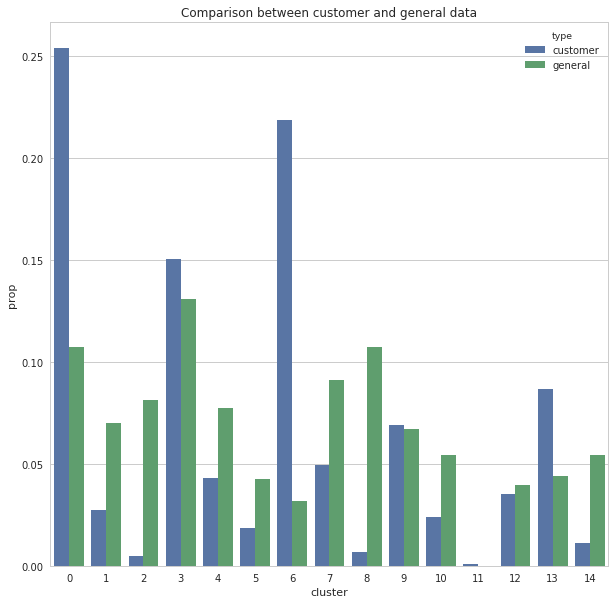

```python
df_combined_prop = pd.concat([df_p_customers_prop_withinfo, df_p_general_prop_withinfo])

f, axes = plt.subplots(1, 1, figsize=(10, 10))
sns.barplot(x='cluster', y='prop', hue='type', data=df_combined_prop);

plt.title('Comparison between customer and general data');
```

```python
def plot_scaled_comparison(df_sample, pca_final, kmeans, cluster):
    '''
    Create a comparison plot
    '''

    inverse_value = pca_final.inverse_transform(model_K.cluster_centers_[cluster])

    X = pd.DataFrame.from_dict(dict(zip(df_sample.columns, inverse_value)), orient='index') \
            .rename(columns={0: 'feature_values'}) \
            .sort_values('feature_values', ascending=False)

    X['feature_values_abs'] = abs(X['feature_values'])

    # Plot the top positive and negative values
    pd.concat((X['feature_values'][:10], X['feature_values'][-10:]), axis=0).plot(kind='barh');
```

```python
# What kinds of people are part of a cluster that is overrepresented in the
# customer data compared to the general population?
```

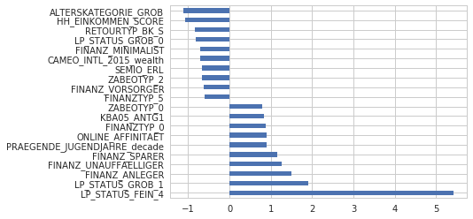

```python
plot_scaled_comparison(customers_scale, pca_final, model_K, cluster_max_over)
```

```python
# What kinds of people are part of a cluster that is underrepresented in the
# customer data compared to the general population?
```

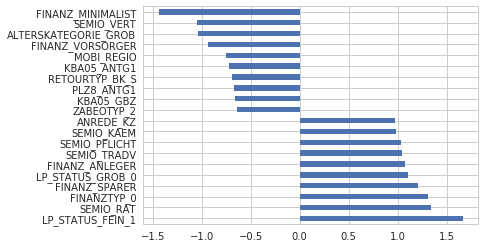

```python
plot_scaled_comparison(customers_scale, pca_final, model_K, cluster_max_under)
```

### Discussion 3.3: Compare Customer Data to Demographics Data

#### Segment of the population that is relatively popular with the mail-order company

A segment of the population that are relatively popular with the mail-order company is a group of people who have very high household net income and are heavy-returner (HH_EINKOMMEN_SCORE, RETOURTYP_BK_S have a large negative value). They are villagers who are not interested in investment (LP_STATUS_FEIN_4 and FINANZ_ANLEGER have a large positive value).

#### Segment of the population that is relatively unpopular with the mail-order company

A segment of the population that are relatively unpopular with the mail-order company is a group of people at younger age who have very low financial interest and low-income (ALTERSKATEGORIE_GROB and FINANZ_MINIMALIST have a high negative value, and LP_STATUS_FEIN_1 has a high positive value).

> Congratulations on making it this far in the project! Before you finish, make sure to check through the entire notebook from top to bottom to make sure that your analysis follows a logical flow and all of your findings are documented in **Discussion** cells. Once you've checked over all of your work, you should export the notebook as an HTML document to submit for evaluation. You can do this from the menu, navigating to **File -> Download as -> HTML (.html)**. You will submit both that document and this notebook for your project submission.

```python
from subprocess import call
call(['python', '-m', 'nbconvert', 'Identify_Customer_Segments.ipynb'])
```

```
0
```